# Match day 10 Season 2627

Result

| Crystal Palace Nketiah 90+5' (pen) | 1 – 3 | Liverpool Mac Allister 40' Wirtz 54' Isak 89' |
| --- | --- | --- |

Crystal Palace vs Liverpool - 08-11-2026 | Premier League MD 10

Liverpool beat Crystal Palace 3–1 with the better of the xG (2.65 vs 2.63). Crystal Palace's peak field tilt was 80% in the 3rd Quarter. Liverpool's peak field tilt was 73% in the 1st Quarter.

xG

CRY 2.63 – 2.65 LIV

xGOT

CRY 2.52 – 2.18 LIV

Field Tilt %

CRY 52% – 48% LIV

PPDA (lower = more intense press)

CRY 16.38 – 12.36 LIV

EPV

CRY 2.78 – 2.56 LIV

EPV to xG Conversion %

CRY 95% – 104% LIV

xG Race

[figure not shown]

Match Momentum

[figure not shown]

Threat Race

[figure not shown]

Field Tilt Momentum

[figure not shown]

Match Report

Summary

- Liverpool beat Crystal Palace 3–1 with the better of the xG (2.65 vs 2.63). Crystal Palace's peak field tilt was 80% in the 3rd Quarter. Liverpool's peak field tilt was 73% in the 1st Quarter.

Set pieces

- **Crystal Palace** took 4 corners, winning first contact on 1 of 4 direct deliveries. Set pieces produced 4 shots worth 0.37 xG (14% of their xG).

- **Liverpool** took 7 corners, winning first contact on 3 of 7 direct deliveries. Set pieces produced 8 shots worth 1.52 xG and 1 goal (57% of their xG).

Transitions

- **Crystal Palace** won the ball in open play 86 times (8 in the attacking third) and had 7 shots within 15 seconds of a regain, worth 0.64 xG.

- **Liverpool** won the ball in open play 94 times (11 in the attacking third) and had 8 shots within 15 seconds of a regain, worth 0.92 xG including 2 goals (Wirtz 54', Isak 89').

Defensive shape

- **Liverpool**'s defensive actions dropped from an average of 50.5m to 30.9m from their own goal between the 1st Quarter and the 2nd Quarter (score 0-0 at the start of the 2nd Quarter), while **Crystal Palace** went from 29.5m to 48.3m over the 2nd Quarter to 3rd Quarter. Standard PPDA: Crystal Palace 16.38, Liverpool 12.36 (lower = more pressing).

Passing chains

- **Crystal Palace** strung together 7 moves of 10+ completed passes (21% of their completed passes came in those moves, 2 ended in a shot). Their longest move was 12 passes (27').

- **Liverpool** strung together 8 moves of 10+ completed passes (34% of their completed passes came in those moves, 2 ended in a shot). Their longest move was 17 passes (55').

Threat areas

- **Crystal Palace** generated most threat from the final third, left half-space (0.73 EPV, 26%), followed by the final third, left wing (0.56).

- **Liverpool** generated most threat from the final third, right wing (0.97 EPV, 38%), followed by the final third, left wing (0.29).

Pass maps

- **Crystal Palace**'s most used combination was Henderson to Disasi (12 completed passes), and Pino was the hub of the pass map, involved in 89 completed passes.

- **Liverpool**'s most used combination was Becker to van Dijk (11 completed passes), and Mac Allister was the hub of the pass map, involved in 74 completed passes.

Crystal Palace Line up

Crystal Palace vs Liverpool - 08-11-2026

| Mins Played | Shirt Number | Player |
| --- | --- | --- |
| Keeper |  |  |
| 99 | 1 | Dean Henderson |
| Defender |  |  |
| 99 | 5 | Axel Disasi |
| 99 | 26 | Chris Richards |
| 99 | 8 | Jefferson Lerma |
| Midfielder |  |  |
| 99 | 20 | Adam Wharton |
| 99 | 3 | Tyrick Mitchell |
| 91 | 30 | Óscar Mingueza |
| 64 | 23 | Quinten Timber |
| 35 | 24 | Darío Osorio |
| 8 | 25 | Anan Khalaili |
| 8 | 11 | Dwight McNeil |
| Forward |  |  |
| 99 | 18 | Daichi Kamada |
| 91 | 10 | Yéremy Pino |
| 76 | 22 | Jørgen Strand Larsen |
| 23 | 9 | Eddie Nketiah |
| Substitute |  |  |
| 0 | 44 | Walter Benítez |
| 0 | 6 | Jaydee Canvot |
| 0 | 19 | Will Hughes |
| 0 | 28 | Cheick Doucouré |
| 0 | 33 | Ben Chilwell |

X @Barts78 · Bluesky @barts78 · Mastodon @DrBarts · GitHub Barts78 · LinkedIn Phil-barter · Data: Opta

Liverpool Line up

Crystal Palace vs Liverpool - 08-11-2026

|  | Shirt Number | Mins Played |
| --- | --- | --- |
| Keeper |  |  |
| Alisson Becker | 1 | 99 |
| Defender |  |  |
| Jérémy Jacquet | 5 | 99 |
| Milos Kerkez | 6 | 99 |
| Virgil van Dijk | 4 | 99 |
| Ronald Araujo | 33 | 95 |
| Joe Gomez | 2 | 4 |
| Midfielder |  |  |
| Alexis Mac Allister | 10 | 99 |
| Florian Wirtz | 7 | 99 |
| Cody Gakpo | 18 | 80 |
| Bradley Barcola | 29 | 73 |
| Dominik Szoboszlai | 8 | 73 |
| Trey Nyoni | 42 | 26 |
| Forward |  |  |
| Alexander Isak | 9 | 95 |
| Víctor Muñoz | 23 | 26 |
| Rio Ngumoha | 73 | 19 |
| Lewis Koumas | 67 | 4 |
| Substitute |  |  |
| Giorgi Mamardashvili | 25 | 0 |
| Wataru Endo | 3 | 0 |
| Kostas Tsimikas | 21 | 0 |
| James McConnell | 53 | 0 |

X @Barts78 · Bluesky @barts78 · Mastodon @DrBarts · GitHub Barts78 · LinkedIn Phil-barter · Data: Opta

**Match Summary tables**

**Match Summary - Full Time**

Crystal Palace vs Liverpool - 08-11-2026

| Possession Possession % | Possession On Ball Time | Possession Touches | Possession PKBox Touches | Possession Field Tilt % | Shots Total Shots | Shots OFF Shots | Shots SoT | Shots 6yrd box Shots | Shots PK Box Shots | Shots Outside Box Shots | Shots Blocked Shots | Shots BCs | Shots Goals | Shots xG | Shots NPxG | Shots xGOT | Threat EPV | Threat EPV % xG Con. | Threat EPV % NPxG Con. | Passes Attempted Passes | Passes Successful Passes | Passes Pass Success % | Passes Long Passes | Passes Long Ball Rate | Passes Crosses | Passes Cross Success % | Passes Corners | Passes Short Corners | PPDO | … |
| --- | --- | --- | --- | --- | --- | --- | --- | --- | --- | --- | --- | --- | --- | --- | --- | --- | --- | --- | --- | --- | --- | --- | --- | --- | --- | --- | --- | --- | --- | --- |
| Crystal Palace |  |  |  |  |  |  |  |  |  |  |  |  |  |  |  |  |  |  |  |  |  |  |  |  |  |  |  |  |  | … |
| 52.1% | 37.60 | 619 | 35 | 51.6% | 19 | 7 | 7 | 1 | 12 | 7 | 5 | 5 | 1 | 2.63 | 1.84 | 2.52 | 2.78 | 94.5% | 66.1% | 420 | 336 | 80.0% | 61 | 14.5% | 22 | 27.3% | 4 | 0 |  | … |
| Liverpool |  |  |  |  |  |  |  |  |  |  |  |  |  |  |  |  |  |  |  |  |  |  |  |  |  |  |  |  |  | … |
| 47.9% | 37.30 | 570 | 40 | 48.4% | 20 | 8 | 8 | 2 | 18 | 2 | 4 | 5 | 3 | 2.65 | 2.65 | 2.18 | 2.56 | 103.4% | 103.4% | 357 | 275 | 77.0% | 65 | 18.2% | 21 | 38.1% | 7 | 0 | 1240 | … |

X @Barts78 · Bluesky @barts78 · Mastodon @DrBarts · GitHub Barts78 · LinkedIn Phil-barter · Data: Opta

**Match Summary - By Half**

Crystal Palace vs Liverpool - 08-11-2026

|  | Possession Possession % | Possession On Ball Time | Possession Touches | Possession PKBox Touches | Possession Field Tilt % | Shots Total Shots | Shots OFF Shots | Shots SoT | Shots 6yrd box Shots | Shots PK Box Shots | Shots Outside Box Shots | Shots Blocked Shots | Shots BCs | Shots Goals | Shots xG | Shots NPxG | Shots xGOT | Threat EPV | Threat EPV % xG Con. | Threat EPV % NPxG Con. | Passes Attempted Passes | Passes Successful Passes | Passes Pass Success % | Passes Long Passes | Passes Long Ball Rate | Passes Crosses | Passes Cross Success % | Passes Corners | Passes Short Corners | … |
| --- | --- | --- | --- | --- | --- | --- | --- | --- | --- | --- | --- | --- | --- | --- | --- | --- | --- | --- | --- | --- | --- | --- | --- | --- | --- | --- | --- | --- | --- | --- |
| First Half |  |  |  |  |  |  |  |  |  |  |  |  |  |  |  |  |  |  |  |  |  |  |  |  |  |  |  |  |  | … |
| Crystal Palace | 48.9% | 18.40 | 292 | 15 | 37.6% | 10 | 3 | 4 | 0 | 7 | 3 | 3 | 2 | 0 | 0.95 | 0.95 | 1.36 | 1.66 | 57.3% | 57.3% | 180 | 143 | 79.4% | 35 | 19.4% | 11 | 45.5% | 2 | 0 | … |
| Liverpool | 51.1% | 18.30 | 305 | 21 | 62.4% | 12 | 6 | 3 | 2 | 10 | 2 | 3 | 2 | 1 | 1.70 | 1.70 | 0.93 | 1.72 | 98.6% | 98.6% | 190 | 152 | 80.0% | 39 | 20.5% | 17 | 35.3% | 5 | 0 | … |
| Second Half |  |  |  |  |  |  |  |  |  |  |  |  |  |  |  |  |  |  |  |  |  |  |  |  |  |  |  |  |  | … |
| Crystal Palace | 55.2% | 19.20 | 327 | 20 | 71.9% | 9 | 4 | 3 | 1 | 5 | 4 | 2 | 3 | 1 | 1.68 | 0.89 | 1.16 | 1.13 | 149.1% | 79.0% | 240 | 193 | 80.4% | 26 | 10.8% | 11 | 9.1% | 2 | 0 | … |
| Liverpool | 44.8% | 19.10 | 265 | 19 | 28.1% | 8 | 2 | 5 | 0 | 8 | 0 | 1 | 3 | 2 | 0.95 | 0.95 | 1.25 | 0.84 | 113.2% | 113.2% | 167 | 123 | 73.7% | 26 | 15.6% | 4 | 50.0% | 2 | 0 | … |

X @Barts78 · Bluesky @barts78 · Mastodon @DrBarts · GitHub Barts78 · LinkedIn Phil-barter · Data: Opta

**Match Summary - By Game Period**

Crystal Palace vs Liverpool - 08-11-2026

|  | Possession Possession % | Possession On Ball Time | Possession Touches | Possession PKBox Touches | Possession Field Tilt % | Shots Total Shots | Shots OFF Shots | Shots ONT Shots | Shots 6yrd box Shots | Shots PK Box Shots | Shots Outside Box Shots | Shots Blocked Shots | Shots BCs | Shots Goals | Shots xG | Shots NPxG | Shots xGOT | Threat EPV | Threat EPV % xG Con. | Threat EPV % NPxG Con. | Passes Attempted Passes | Passes Successful Passes | Passes Pass Success % | Passes Long Passes | Passes Long Ball Rate | Passes Crosses | Passes Cross Success % | Passes Corners | Passes Short Corners | … |
| --- | --- | --- | --- | --- | --- | --- | --- | --- | --- | --- | --- | --- | --- | --- | --- | --- | --- | --- | --- | --- | --- | --- | --- | --- | --- | --- | --- | --- | --- | --- |
| 0 - 15 |  |  |  |  |  |  |  |  |  |  |  |  |  |  |  |  |  |  |  |  |  |  |  |  |  |  |  |  |  | … |
| Crystal Palace | 39.3% | 6.90 | 83 | 2 | 13.1% | 0 | 0 | 0 | 0 | 0 | 0 | 0 | 0 | 0 | 0.00 | 0.00 | 0.00 | 0.63 | 0.0% | 0.0% | 46 | 33 | 71.7% | 10 | 21.7% | 2 | 100.0% | 0 | 0 | … |
| Liverpool | 60.7% | 7.10 | 128 | 10 | 86.9% | 4 | 2 | 1 | 0 | 2 | 2 | 1 | 0 | 0 | 0.12 | 0.12 | 0.02 | 0.64 | 18.7% | 18.7% | 88 | 73 | 83.0% | 14 | 15.9% | 8 | 25.0% | 2 | 0 | … |
| 16 - 30 |  |  |  |  |  |  |  |  |  |  |  |  |  |  |  |  |  |  |  |  |  |  |  |  |  |  |  |  |  | … |
| Crystal Palace | 53.7% | 5.40 | 110 | 4 | 56.1% | 2 | 1 | 1 | 0 | 2 | 0 | 0 | 0 | 0 | 0.12 | 0.12 | 0.23 | 0.46 | 26.1% | 26.1% | 74 | 63 | 85.1% | 13 | 17.6% | 2 | 50.0% | 0 | 0 | … |
| Liverpool | 46.3% | 5.70 | 95 | 4 | 43.9% | 2 | 2 | 0 | 0 | 2 | 0 | 0 | 0 | 0 | 0.15 | 0.15 | 0.00 | 0.38 | 39.7% | 39.7% | 63 | 52 | 82.5% | 13 | 20.6% | 4 | 25.0% | 2 | 0 | … |
| 31 - 45 |  |  |  |  |  |  |  |  |  |  |  |  |  |  |  |  |  |  |  |  |  |  |  |  |  |  |  |  |  | … |
| Crystal Palace | 54.7% | 6.10 | 99 | 9 | 59.0% | 8 | 2 | 3 | 0 | 5 | 3 | 3 | 2 | 0 | 0.83 | 0.83 | 1.13 | 0.56 | 147.2% | 147.2% | 60 | 47 | 78.3% | 12 | 20.0% | 7 | 28.6% | 2 | 0 | … |
| Liverpool | 45.3% | 5.50 | 82 | 7 | 41.0% | 6 | 2 | 2 | 2 | 6 | 0 | 2 | 2 | 1 | 1.43 | 1.43 | 0.91 | 0.70 | 203.1% | 203.1% | 39 | 27 | 69.2% | 12 | 30.8% | 5 | 60.0% | 1 | 0 | … |
| 46 - 60 |  |  |  |  |  |  |  |  |  |  |  |  |  |  |  |  |  |  |  |  |  |  |  |  |  |  |  |  |  | … |
| Crystal Palace | 51.7% | 5.30 | 93 | 4 | 66.7% | 1 | 1 | 0 | 0 | 0 | 1 | 0 | 0 | 0 | 0.02 | 0.02 | 0.00 | 0.25 | 8.1% | 8.1% | 70 | 53 | 75.7% | 7 | 10.0% | 3 | 0.0% | 0 | 0 | … |
| Liverpool | 48.3% | 7.20 | 87 | 4 | 33.3% | 3 | 1 | 1 | 0 | 3 | 0 | 1 | 1 | 1 | 0.30 | 0.30 | 0.41 | 0.37 | 82.2% | 82.2% | 52 | 41 | 78.8% | 8 | 15.4% | 3 | 66.7% | 1 | 0 | … |
| 61 - 75 |  |  |  |  |  |  |  |  |  |  |  |  |  |  |  |  |  |  |  |  |  |  |  |  |  |  |  |  |  | … |
| Crystal Palace | 60.0% | 5.80 | 123 | 4 | 90.7% | 1 | 0 | 0 | 0 | 0 | 1 | 1 | 0 | 0 | 0.03 | 0.03 | 0.00 | 0.28 | 10.6% | 10.6% | 93 | 80 | 86.0% | 7 | 7.5% | 3 | 0.0% | 0 | 0 | … |
| Liverpool | 40.0% | 5.70 | 82 | 2 | 9.3% | 0 | 0 | 0 | 0 | 0 | 0 | 0 | 0 | 0 | 0.00 | 0.00 | 0.00 | 0.08 | 0.0% | 0.0% | 55 | 36 | 65.5% | 10 | 18.2% | 1 | 0.0% | 1 | 0 | … |
| 76 - 90 |  |  |  |  |  |  |  |  |  |  |  |  |  |  |  |  |  |  |  |  |  |  |  |  |  |  |  |  |  | … |
| Crystal Palace | 56.2% | 5.60 | 99 | 9 | 56.2% | 5 | 2 | 2 | 1 | 3 | 2 | 1 | 2 | 0 | 0.77 | 0.77 | 0.24 | 0.58 | 133.0% | 133.0% | 70 | 54 | 77.1% | 10 | 14.3% | 4 | 25.0% | 2 | 0 | … |
| Liverpool | 43.8% | 5.50 | 77 | 13 | 43.8% | 5 | 1 | 4 | 0 | 5 | 0 | 0 | 2 | 1 | 0.65 | 0.65 | 0.84 | 0.37 | 177.6% | 177.6% | 43 | 31 | 72.1% | 6 | 13.9% | 0 | 0.0% | 0 | 0 | … |
| 90 + |  |  |  |  |  |  |  |  |  |  |  |  |  |  |  |  |  |  |  |  |  |  |  |  |  |  |  |  |  | … |
| Crystal Palace | 38.7% | 2.50 | 12 | 3 | 100.0% | 2 | 1 | 1 | 0 | 2 | 0 | 0 | 1 | 1 | 0.86 | 0.07 | 0.92 | 0.02 | 5,375.0% | 437.5% | 7 | 6 | 85.7% | 2 | 28.6% | 1 | 0.0% | 0 | 0 | … |
| Liverpool | 61.3% | 0.70 | 19 | 0 | 0.0% | 0 | 0 | 0 | 0 | 0 | 0 | 0 | 0 | 0 | 0.00 | 0.00 | 0.00 | 0.03 | 0.0% | 0.0% | 17 | 15 | 88.2% | 2 | 11.8% | 0 | 0.0% | 0 | 0 | … |

X @Barts78 · Bluesky @barts78 · Mastodon @DrBarts · GitHub Barts78 · LinkedIn Phil-barter · Data: Opta

**Match Summary - By Game Quarter**

Crystal Palace vs Liverpool - 08-11-2026

|  | Possession Possession % | Possession On Ball Time | Possession Touches | Possession PKBox Touches | Possession Field Tilt % | Shots Total Shots | Shots OFF Shots | Shots ONT Shots | Shots 6yrd box Shots | Shots PK Box Shots | Shots Outside Box Shots | Shots Blocked Shots | Shots BCs | Shots Goals | Shots xG | Shots NPxG | Shots xGOT | Threat EPV | Threat EPV % xG Con. | Threat EPV % NPxG Con. | Passes Attempted Passes | Passes Successful Passes | Passes Pass Success % | Passes Long Passes | Passes Long Ball Rate | Passes Crosses | Passes Cross Success % | Passes Corners | Passes Short Corners | … |
| --- | --- | --- | --- | --- | --- | --- | --- | --- | --- | --- | --- | --- | --- | --- | --- | --- | --- | --- | --- | --- | --- | --- | --- | --- | --- | --- | --- | --- | --- | --- |
| 1st Quarter |  |  |  |  |  |  |  |  |  |  |  |  |  |  |  |  |  |  |  |  |  |  |  |  |  |  |  |  |  | … |
| Crystal Palace | 46.4% | 10.60 | 161 | 6 | 27.2% | 2 | 1 | 1 | 0 | 2 | 0 | 0 | 0 | 0 | 0.12 | 0.12 | 0.23 | 1.01 | 11.9% | 11.9% | 98 | 76 | 77.6% | 18 | 18.4% | 4 | 75.0% | 0 | 0 | … |
| Liverpool | 53.6% | 10.90 | 186 | 12 | 72.8% | 5 | 3 | 1 | 0 | 3 | 2 | 1 | 0 | 0 | 0.22 | 0.22 | 0.02 | 0.79 | 27.9% | 27.9% | 120 | 101 | 84.2% | 23 | 19.2% | 11 | 18.2% | 3 | 0 | … |
| 2nd Quarter |  |  |  |  |  |  |  |  |  |  |  |  |  |  |  |  |  |  |  |  |  |  |  |  |  |  |  |  |  | … |
| Crystal Palace | 52.4% | 7.80 | 131 | 9 | 54.2% | 8 | 2 | 3 | 0 | 5 | 3 | 3 | 2 | 0 | 0.83 | 0.83 | 1.13 | 0.65 | 128.7% | 128.7% | 82 | 67 | 81.7% | 17 | 20.7% | 7 | 28.6% | 2 | 0 | … |
| Liverpool | 47.6% | 7.40 | 119 | 9 | 45.8% | 7 | 3 | 2 | 2 | 7 | 0 | 2 | 2 | 1 | 1.48 | 1.48 | 0.91 | 0.94 | 158.1% | 158.1% | 70 | 51 | 72.9% | 16 | 22.9% | 6 | 66.7% | 2 | 0 | … |
| 3rd Quarter |  |  |  |  |  |  |  |  |  |  |  |  |  |  |  |  |  |  |  |  |  |  |  |  |  |  |  |  |  | … |
| Crystal Palace | 55.5% | 9.50 | 176 | 8 | 79.7% | 1 | 1 | 0 | 0 | 0 | 1 | 0 | 0 | 0 | 0.02 | 0.02 | 0.00 | 0.47 | 4.2% | 4.2% | 133 | 108 | 81.2% | 10 | 7.5% | 6 | 0.0% | 0 | 0 | … |
| Liverpool | 44.5% | 11.00 | 141 | 6 | 20.3% | 3 | 1 | 1 | 0 | 3 | 0 | 1 | 1 | 1 | 0.30 | 0.30 | 0.41 | 0.42 | 72.1% | 72.1% | 87 | 66 | 75.9% | 15 | 17.2% | 4 | 50.0% | 2 | 0 | … |
| 4th Quarter |  |  |  |  |  |  |  |  |  |  |  |  |  |  |  |  |  |  |  |  |  |  |  |  |  |  |  |  |  | … |
| Crystal Palace | 54.9% | 9.70 | 151 | 12 | 62.7% | 8 | 3 | 3 | 1 | 5 | 3 | 2 | 3 | 1 | 1.66 | 0.87 | 1.16 | 0.65 | 253.8% | 133.0% | 107 | 85 | 79.4% | 16 | 14.9% | 5 | 20.0% | 2 | 0 | … |
| Liverpool | 45.1% | 8.10 | 124 | 13 | 37.3% | 5 | 1 | 4 | 0 | 5 | 0 | 0 | 2 | 1 | 0.65 | 0.65 | 0.84 | 0.42 | 153.7% | 153.7% | 80 | 57 | 71.2% | 11 | 13.8% | 0 | 0.0% | 0 | 0 | … |

X @Barts78 · Bluesky @barts78 · Mastodon @DrBarts · GitHub Barts78 · LinkedIn Phil-barter · Data: Opta

**Match Summary - By Game State**

Crystal Palace vs Liverpool - 08-11-2026

|  | Possession Possession % | Possession On Ball Time | Possession Touches | Possession PKBox Touches | Possession Field Tilt % | Shots Total Shots | Shots OFF Shots | Shots SoT | Shots 6yrd box Shots | Shots PK Box Shots | Shots Outside Box Shots | Shots Blocked Shots | Shots BCs | Shots Goals | Shots xG | Shots NPxG | Shots xGOT | Threat EPV | Threat EPV % xG Con. | Threat EPV % NPxG Con. | Passes Attempted Passes | Passes Successful Passes | Passes Pass Success % | Passes Long Passes | Passes Long Ball Rate | Passes Crosses | Passes Cross Success % | Passes Corners | Passes Short Corners | … |
| --- | --- | --- | --- | --- | --- | --- | --- | --- | --- | --- | --- | --- | --- | --- | --- | --- | --- | --- | --- | --- | --- | --- | --- | --- | --- | --- | --- | --- | --- | --- |
| Away Garbage Time |  |  |  |  |  |  |  |  |  |  |  |  |  |  |  |  |  |  |  |  |  |  |  |  |  |  |  |  |  | … |
| Crystal Palace | 54.7% | 15.10 | 261 | 17 | 69.2% | 8 | 3 | 3 | 1 | 5 | 3 | 2 | 3 | 1 | 1.66 | 0.87 | 1.16 | 0.93 | 178.5% | 93.5% | 190 | 155 | 81.6% | 21 | 11.1% | 9 | 11.1% | 2 | 0 | … |
| Liverpool | 45.3% | 14.90 | 216 | 17 | 30.8% | 7 | 2 | 4 | 0 | 7 | 0 | 1 | 2 | 1 | 0.76 | 0.76 | 0.84 | 0.72 | 106.3% | 106.3% | 140 | 104 | 74.3% | 21 | 15.0% | 2 | 50.0% | 2 | 0 | … |
| Away Lead |  |  |  |  |  |  |  |  |  |  |  |  |  |  |  |  |  |  |  |  |  |  |  |  |  |  |  |  |  | … |
| Crystal Palace | 60.2% | 7.40 | 124 | 6 | 81.1% | 5 | 1 | 2 | 0 | 2 | 3 | 2 | 1 | 0 | 0.36 | 0.36 | 0.80 | 0.52 | 68.7% | 68.7% | 90 | 71 | 78.9% | 10 | 11.1% | 7 | 14.3% | 2 | 0 | … |
| Liverpool | 39.8% | 5.20 | 82 | 6 | 18.9% | 4 | 1 | 2 | 2 | 4 | 0 | 1 | 2 | 1 | 1.17 | 1.17 | 0.85 | 0.41 | 285.4% | 285.4% | 38 | 24 | 63.2% | 12 | 31.6% | 3 | 66.7% | 1 | 0 | … |
| Draw |  |  |  |  |  |  |  |  |  |  |  |  |  |  |  |  |  |  |  |  |  |  |  |  |  |  |  |  |  | … |
| Crystal Palace | 46.2% | 15.10 | 234 | 12 | 29.9% | 6 | 3 | 2 | 0 | 5 | 1 | 1 | 1 | 0 | 0.61 | 0.61 | 0.56 | 1.33 | 45.9% | 45.9% | 140 | 110 | 78.6% | 30 | 21.4% | 6 | 66.7% | 0 | 0 | … |
| Liverpool | 53.8% | 17.20 | 272 | 17 | 70.1% | 9 | 5 | 2 | 0 | 7 | 2 | 2 | 1 | 1 | 0.72 | 0.72 | 0.49 | 1.44 | 50.1% | 50.1% | 179 | 147 | 82.1% | 32 | 17.9% | 16 | 31.2% | 4 | 0 | … |

X @Barts78 · Bluesky @barts78 · Mastodon @DrBarts · GitHub Barts78 · LinkedIn Phil-barter · Data: Opta

**Season Summary Tables**

**Season Summary - Full Games**

Up to Crystal Palace vs Liverpool - 08-11-2026

| Possession % | Touches | PKBox Touches | Field Tilt % | Total Shots | OFF Shots | SoT | 6yrd box Shots | PK Box Shots | Outside Box Shots | BCs | Goals | xG | NPxG | xGOT | EPV | EPV % xG Con. | Attempted Passes | Successful Passes | Pass Success % | Long Passes | Long Ball Rate | Crosses | Cross Success % | Corners | Short Corners | Possession Control | Poss Control /100 Touches | EPV % NPxG Con. |
| --- | --- | --- | --- | --- | --- | --- | --- | --- | --- | --- | --- | --- | --- | --- | --- | --- | --- | --- | --- | --- | --- | --- | --- | --- | --- | --- | --- | --- |
| All Oppo |  |  |  |  |  |  |  |  |  |  |  |  |  |  |  |  |  |  |  |  |  |  |  |  |  |  |  |  |
| 48.0% | 6,175 | 261 | 43.7% | 129 | 52 | 34 | 14 | 79 | 50 | 20 | 10 | 13.09 | 11.51 | 12.15 | 20.80 | 62.9% | 4035 | 3195 | 79.2% | 581 | 14.4% | 156 | 22.4% | 41 | 9 | -919 | -14.9 | 55.3% |
| Liverpool |  |  |  |  |  |  |  |  |  |  |  |  |  |  |  |  |  |  |  |  |  |  |  |  |  |  |  |  |
| 52.0% | 6,695 | 300 | 56.3% | 160 | 56 | 47 | 13 | 103 | 57 | 17 | 14 | 15.15 | 14.36 | 14.11 | 23.72 | 63.9% | 4513 | 3731 | 82.7% | 510 | 11.3% | 193 | 20.7% | 52 | 9 | -816 | -12.2 | 60.5% |

X @Barts78 · Bluesky @barts78 · Mastodon @DrBarts · GitHub Barts78 · LinkedIn Phil-barter · Data: Opta

**Season Summary - By Half**

Up to Crystal Palace vs Liverpool - 08-11-2026

|  | Possession Possession % | Possession Touches | Possession PKBox Touches | Possession Field Tilt % | Shots Total Shots | Shots OFF Shots | Shots SoT | Shots 6yrd box Shots | Shots PK Box Shots | Shots Outside Box Shots | Shots BCs | Shots Goals | Shots xG | Shots NPxG | Shots xGOT | Threat EPV | Threat EPV % xG Con. | Threat EPV % NPxG Con. | Passes Attempted Passes | Passes Successful Passes | Passes Pass Success % | Passes Long Passes | Passes Long Ball Rate | Passes Crosses | Passes Cross Success % | Passes Corners | Passes Short Corners | Possession Control | Poss Control /100 Touches | … |
| --- | --- | --- | --- | --- | --- | --- | --- | --- | --- | --- | --- | --- | --- | --- | --- | --- | --- | --- | --- | --- | --- | --- | --- | --- | --- | --- | --- | --- | --- | --- |
| First Half |  |  |  |  |  |  |  |  |  |  |  |  |  |  |  |  |  |  |  |  |  |  |  |  |  |  |  |  |  | … |
| All Oppo | 47.8% | 3,069 | 132 | 41.2% | 62 | 22 | 16 | 8 | 43 | 19 | 10 | 4 | 5.76 | 5.76 | 5.41 | 11.07 | 52.0% | 52.0% | 1998 | 1577 | 78.9% | 291 | 14.6% | 72 | 23.6% | 22 | 6 |  |  | … |
| Liverpool | 52.2% | 3,356 | 148 | 58.8% | 74 | 32 | 20 | 6 | 44 | 30 | 7 | 5 | 6.03 | 6.03 | 4.97 | 11.98 | 50.3% | 50.3% | 2299 | 1883 | 81.9% | 262 | 11.4% | 98 | 22.4% | 31 | 5 | -396 | -11.8 | … |
| Second Half |  |  |  |  |  |  |  |  |  |  |  |  |  |  |  |  |  |  |  |  |  |  |  |  |  |  |  |  |  | … |
| All Oppo | 48.2% | 3,106 | 129 | 46.0% | 67 | 30 | 18 | 6 | 36 | 31 | 10 | 6 | 7.33 | 5.75 | 6.74 | 9.73 | 75.3% | 59.1% | 2037 | 1618 | 79.4% | 290 | 14.2% | 84 | 21.4% | 19 | 3 | -438 | -14.1 | … |
| Liverpool | 51.8% | 3,339 | 152 | 54.0% | 86 | 24 | 27 | 7 | 59 | 27 | 10 | 9 | 9.12 | 8.33 | 9.14 | 11.73 | 77.7% | 71.0% | 2214 | 1848 | 83.5% | 248 | 11.2% | 95 | 18.9% | 21 | 4 | -420 | -12.6 | … |

X @Barts78 · Bluesky @barts78 · Mastodon @DrBarts · GitHub Barts78 · LinkedIn Phil-barter · Data: Opta

**Season Summary - By Game Period**

Up to Crystal Palace vs Liverpool - 08-11-2026

|  | Possession Possession % | Possession Touches | Possession PKBox Touches | Possession Field Tilt % | Shots Total Shots | Shots OFF Shots | Shots ONT Shots | Shots 6yrd box Shots | Shots PK Box Shots | Shots Outside Box Shots | Shots BCs | Shots Goals | Shots xG | Shots NPxG | Shots xGOT | Threat EPV | Threat EPV % xG Con. | Threat EPV % NPxG Con. | Passes Attempted Passes | Passes Successful Passes | Passes Pass Success % | Passes Long Passes | Passes Long Ball Rate | Passes Crosses | Passes Cross Success % | Passes Corners | Passes Short Corners | Possession Control | Poss Control /100 Touches | … |
| --- | --- | --- | --- | --- | --- | --- | --- | --- | --- | --- | --- | --- | --- | --- | --- | --- | --- | --- | --- | --- | --- | --- | --- | --- | --- | --- | --- | --- | --- | --- |
| 0 - 15 |  |  |  |  |  |  |  |  |  |  |  |  |  |  |  |  |  |  |  |  |  |  |  |  |  |  |  |  |  | … |
| All Oppo | 47.5% | 1,074 | 33 | 40.6% | 12 | 5 | 2 | 2 | 7 | 5 | 5 | 2 | 1.97 | 1.97 | 1.19 | 3.74 | 52.7% | 52.7% | 717 | 546 | 76.2% | 115 | 16.0% | 19 | 21.1% | 5 | 3 |  |  | … |
| Liverpool | 52.5% | 1,186 | 39 | 59.4% | 15 | 6 | 4 | 0 | 10 | 5 | 0 | 2 | 0.95 | 0.95 | 0.47 | 3.45 | 27.5% | 27.5% | 839 | 649 | 77.4% | 109 | 13.0% | 24 | 16.7% | 7 | 2 | -160 | -13.5 | … |
| 16 - 30 |  |  |  |  |  |  |  |  |  |  |  |  |  |  |  |  |  |  |  |  |  |  |  |  |  |  |  |  |  | … |
| All Oppo | 46.7% | 940 | 45 | 40.0% | 20 | 5 | 5 | 4 | 17 | 3 | 2 | 1 | 1.52 | 1.52 | 1.91 | 3.33 | 45.7% | 45.7% | 581 | 471 | 81.1% | 75 | 12.9% | 25 | 32.0% | 8 | 2 | -150 | -16.0 | … |
| Liverpool | 53.3% | 1,074 | 54 | 60.0% | 29 | 13 | 8 | 3 | 16 | 13 | 3 | 2 | 2.26 | 2.26 | 3.08 | 3.97 | 56.9% | 56.9% | 732 | 625 | 85.4% | 73 | 10.0% | 37 | 18.9% | 12 | 1 | -97 | -9.0 | … |
| 31 - 45 |  |  |  |  |  |  |  |  |  |  |  |  |  |  |  |  |  |  |  |  |  |  |  |  |  |  |  |  |  | … |
| All Oppo | 49.0% | 1,055 | 54 | 42.9% | 30 | 12 | 9 | 2 | 19 | 11 | 3 | 1 | 2.27 | 2.27 | 2.31 | 4.00 | 56.8% | 56.8% | 700 | 560 | 80.0% | 101 | 14.4% | 28 | 17.9% | 9 | 1 | -151 | -14.3 | … |
| Liverpool | 51.0% | 1,096 | 55 | 57.1% | 30 | 13 | 8 | 3 | 18 | 12 | 4 | 1 | 2.82 | 2.82 | 1.42 | 4.56 | 61.9% | 61.9% | 728 | 609 | 83.7% | 80 | 11.0% | 37 | 29.7% | 12 | 2 | -139 | -12.7 | … |
| 46 - 60 |  |  |  |  |  |  |  |  |  |  |  |  |  |  |  |  |  |  |  |  |  |  |  |  |  |  |  |  |  | … |
| All Oppo | 42.5% | 908 | 38 | 33.3% | 16 | 11 | 3 | 1 | 9 | 7 | 2 | 1 | 1.36 | 1.36 | 1.57 | 2.44 | 55.7% | 55.7% | 547 | 409 | 74.8% | 88 | 16.1% | 21 | 14.3% | 3 | 1 | -132 | -14.5 | … |
| Liverpool | 57.5% | 1,226 | 48 | 66.7% | 35 | 10 | 10 | 4 | 24 | 11 | 5 | 4 | 4.30 | 4.30 | 3.63 | 4.73 | 90.8% | 90.8% | 834 | 702 | 84.2% | 81 | 9.7% | 38 | 23.7% | 8 | 1 | -154 | -12.6 | … |
| 61 - 75 |  |  |  |  |  |  |  |  |  |  |  |  |  |  |  |  |  |  |  |  |  |  |  |  |  |  |  |  |  | … |
| All Oppo | 49.4% | 955 | 49 | 54.0% | 23 | 8 | 9 | 2 | 14 | 9 | 3 | 3 | 2.35 | 1.56 | 2.68 | 3.45 | 68.0% | 45.2% | 643 | 526 | 81.8% | 90 | 14.0% | 29 | 31.0% | 7 | 1 | -127 | -13.3 | … |
| Liverpool | 50.6% | 977 | 44 | 46.0% | 19 | 5 | 7 | 1 | 11 | 8 | 0 | 2 | 1.55 | 1.55 | 1.85 | 2.75 | 56.3% | 56.3% | 659 | 547 | 83.0% | 81 | 12.3% | 25 | 8.0% | 8 | 3 | -109 | -11.2 | … |
| 76 - 90 |  |  |  |  |  |  |  |  |  |  |  |  |  |  |  |  |  |  |  |  |  |  |  |  |  |  |  |  |  | … |
| All Oppo | 52.5% | 976 | 35 | 49.2% | 20 | 8 | 4 | 3 | 9 | 11 | 4 | 1 | 2.57 | 2.57 | 1.44 | 3.26 | 78.8% | 78.8% | 671 | 542 | 80.8% | 83 | 12.4% | 30 | 20.0% | 7 | 0 | -138 | -14.1 | … |
| Liverpool | 47.5% | 884 | 48 | 50.8% | 25 | 6 | 7 | 2 | 20 | 5 | 3 | 2 | 1.99 | 1.99 | 2.53 | 3.24 | 61.5% | 61.5% | 564 | 468 | 83.0% | 64 | 11.3% | 22 | 22.7% | 4 | 0 | -127 | -14.4 | … |
| 90 + |  |  |  |  |  |  |  |  |  |  |  |  |  |  |  |  |  |  |  |  |  |  |  |  |  |  |  |  |  | … |
| All Oppo | 51.4% | 267 | 7 | 51.0% | 8 | 3 | 2 | 0 | 4 | 4 | 1 | 1 | 1.05 | 0.26 | 1.05 | 0.57 | 183.9% | 45.5% | 176 | 141 | 80.1% | 29 | 16.5% | 4 | 0.0% | 2 | 1 | -41 | -15.4 | … |
| Liverpool | 48.6% | 252 | 12 | 49.0% | 7 | 3 | 3 | 0 | 4 | 3 | 2 | 1 | 1.28 | 0.49 | 1.13 | 1.01 | 126.5% | 48.4% | 157 | 131 | 83.4% | 22 | 14.0% | 10 | 20.0% | 1 | 0 | -30 | -11.9 | … |

X @Barts78 · Bluesky @barts78 · Mastodon @DrBarts · GitHub Barts78 · LinkedIn Phil-barter · Data: Opta

**Season Summary - By Game State**

Up to Crystal Palace vs Liverpool - 08-11-2026

|  | Possession Possession % | Possession Touches | Possession PKBox Touches | Possession Field Tilt % | Shots Total Shots | Shots OFF Shots | Shots SoT | Shots 6yrd box Shots | Shots PK Box Shots | Shots Outside Box Shots | Shots BCs | Shots Goals | Shots xG | Shots NPxG | Shots xGOT | Threat EPV | Threat EPV % xG Con. | Threat EPV % NPxG Con. | Passes Attempted Passes | Passes Successful Passes | Passes Pass Success % | Passes Long Passes | Passes Long Ball Rate | Passes Crosses | Passes Cross Success % | Passes Corners | Passes Short Corners | Possession Control | Poss Control /100 Touches | … |
| --- | --- | --- | --- | --- | --- | --- | --- | --- | --- | --- | --- | --- | --- | --- | --- | --- | --- | --- | --- | --- | --- | --- | --- | --- | --- | --- | --- | --- | --- | --- |
| Away Garbage Time |  |  |  |  |  |  |  |  |  |  |  |  |  |  |  |  |  |  |  |  |  |  |  |  |  |  |  |  |  | … |
| All Oppo | 53.5% | 1,084 | 46 | 61.3% | 30 | 12 | 9 | 4 | 12 | 18 | 4 | 2 | 3.43 | 2.64 | 2.84 | 3.53 | 97.1% | 74.7% | 799 | 687 | 86.0% | 73 | 9.1% | 26 | 26.9% | 8 | 1 |  |  | … |
| Liverpool | 46.5% | 944 | 34 | 38.7% | 16 | 3 | 10 | 0 | 10 | 6 | 2 | 1 | 1.29 | 1.29 | 3.04 | 2.77 | 46.5% | 46.5% | 648 | 548 | 84.6% | 78 | 12.0% | 11 | 27.3% | 5 | 0 | -87 | -9.2 | … |
| Away Lead |  |  |  |  |  |  |  |  |  |  |  |  |  |  |  |  |  |  |  |  |  |  |  |  |  |  |  |  |  | … |
| All Oppo | 45.0% | 1,308 | 52 | 38.4% | 23 | 9 | 7 | 2 | 14 | 9 | 1 | 1 | 1.47 | 1.47 | 2.29 | 4.26 | 34.5% | 34.5% | 785 | 581 | 74.0% | 138 | 17.6% | 37 | 24.3% | 8 | 1 | -204 | -15.6 | … |
| Liverpool | 55.0% | 1,601 | 89 | 61.6% | 39 | 13 | 10 | 4 | 30 | 9 | 4 | 4 | 4.56 | 4.56 | 3.24 | 6.80 | 67.1% | 67.1% | 1071 | 900 | 84.0% | 103 | 9.6% | 63 | 17.5% | 15 | 3 | -203 | -12.7 | … |
| Draw |  |  |  |  |  |  |  |  |  |  |  |  |  |  |  |  |  |  |  |  |  |  |  |  |  |  |  |  |  | … |
| All Oppo | 46.5% | 2,546 | 107 | 41.1% | 47 | 17 | 14 | 6 | 37 | 10 | 13 | 7 | 5.69 | 4.90 | 5.99 | 9.09 | 62.6% | 53.9% | 1657 | 1286 | 77.6% | 263 | 15.9% | 63 | 20.6% | 21 | 7 | -414 | -16.3 | … |
| Liverpool | 53.5% | 2,932 | 106 | 58.9% | 63 | 28 | 15 | 4 | 38 | 25 | 7 | 5 | 5.39 | 5.39 | 3.64 | 9.92 | 54.3% | 54.3% | 2037 | 1671 | 82.0% | 235 | 11.5% | 84 | 19.1% | 19 | 4 | -366 | -12.5 | … |
| Home Garbage Time |  |  |  |  |  |  |  |  |  |  |  |  |  |  |  |  |  |  |  |  |  |  |  |  |  |  |  |  |  | … |
| All Oppo | 62.7% | 657 | 37 | 68.4% | 16 | 8 | 1 | 1 | 9 | 7 | 0 | 0 | 1.09 | 1.09 | 0.09 | 2.58 | 42.3% | 42.3% | 472 | 404 | 85.6% | 45 | 9.5% | 21 | 23.8% | 2 | 0 | -90 | -13.7 | … |
| Liverpool | 37.3% | 391 | 18 | 31.6% | 8 | 4 | 1 | 2 | 5 | 3 | 0 | 0 | 0.66 | 0.66 | 0.05 | 1.21 | 54.5% | 54.5% | 223 | 157 | 70.4% | 44 | 19.7% | 4 | 50.0% | 4 | 0 | -57 | -14.6 | … |
| Home Lead |  |  |  |  |  |  |  |  |  |  |  |  |  |  |  |  |  |  |  |  |  |  |  |  |  |  |  |  |  | … |
| All Oppo | 41.2% | 580 | 19 | 26.8% | 13 | 6 | 3 | 1 | 7 | 6 | 2 | 0 | 1.41 | 1.41 | 0.94 | 1.34 | 105.5% | 105.5% | 322 | 237 | 73.6% | 62 | 19.2% | 9 | 11.1% | 2 | 0 | -94 | -16.2 | … |
| Liverpool | 58.8% | 827 | 53 | 73.2% | 34 | 8 | 11 | 3 | 20 | 14 | 4 | 4 | 3.25 | 2.46 | 4.14 | 3.01 | 108.0% | 81.7% | 534 | 455 | 85.2% | 50 | 9.4% | 31 | 25.8% | 9 | 2 | -103 | -12.5 | … |

X @Barts78 · Bluesky @barts78 · Mastodon @DrBarts · GitHub Barts78 · LinkedIn Phil-barter · Data: Opta

**Season Summary - By Match Day**

Up to Crystal Palace vs Liverpool - 08-11-2026

|  | Fixture | Possession Possession % | Possession Touches | Possession PKBox Touches | Possession Field Tilt % | Shots Total Shots | Shots OFF Shots | Shots SoT | Shots 6yrd box Shots | Shots PK Box Shots | Shots Outside Box Shots | Shots BCs | Shots Goals | Shots xG | Shots NPxG | Shots xGOT | Threat EPV | Threat EPV % xG Con. | Threat EPV % NPxG Con. | Passes Attempted Passes | Passes Successful Passes | Passes Pass Success % | Passes Long Passes | Passes Long Ball Rate | Passes Crosses | Passes Cross Success % | Passes Corners | Passes Short Corners | Possession Control | … |
| --- | --- | --- | --- | --- | --- | --- | --- | --- | --- | --- | --- | --- | --- | --- | --- | --- | --- | --- | --- | --- | --- | --- | --- | --- | --- | --- | --- | --- | --- | --- |
| 1 |  |  |  |  |  |  |  |  |  |  |  |  |  |  |  |  |  |  |  |  |  |  |  |  |  |  |  |  |  | … |
| All Oppo | Newcastle vs Liverpool | 43.8% | 518 | 16 | 31.2% | 13 | 5 | 4 | 1 | 6 | 7 | 3 | 2 | 1.43 | 1.43 | 1.30 | 1.23 | 116.1% | 116.1% | 292 | 222 | 76.0% | 50 | 17.1% | 8 | 12.5% | 2 | 0 |  | … |
| Liverpool | Newcastle vs Liverpool | 56.2% | 666 | 39 | 68.8% | 27 | 4 | 7 | 2 | 16 | 11 | 3 | 2 | 2.74 | 1.95 | 2.73 | 2.24 | 122.3% | 87.1% | 440 | 370 | 84.1% | 47 | 10.7% | 27 | 25.9% | 6 | 0 | -91 | … |
| 2 |  |  |  |  |  |  |  |  |  |  |  |  |  |  |  |  |  |  |  |  |  |  |  |  |  |  |  |  |  | … |
| All Oppo | Liverpool vs Nottingham Forest | 37.2% | 520 | 23 | 28.1% | 12 | 3 | 3 | 3 | 11 | 1 | 5 | 2 | 2.30 | 1.51 | 1.28 | 1.89 | 121.5% | 79.8% | 288 | 193 | 67.0% | 75 | 26.0% | 7 | 28.6% | 5 | 0 | -84 | … |
| Liverpool | Liverpool vs Nottingham Forest | 62.8% | 878 | 23 | 71.9% | 13 | 5 | 4 | 1 | 8 | 5 | 1 | 2 | 1.73 | 1.73 | 2.02 | 3.38 | 51.2% | 51.2% | 631 | 562 | 89.1% | 46 | 7.3% | 30 | 16.7% | 3 | 1 | -97 | … |
| 3 |  |  |  |  |  |  |  |  |  |  |  |  |  |  |  |  |  |  |  |  |  |  |  |  |  |  |  |  |  | … |
| All Oppo | Ipswich vs Liverpool | 45.4% | 620 | 16 | 43.0% | 14 | 5 | 5 | 2 | 4 | 10 | 0 | 0 | 0.76 | 0.76 | 0.76 | 1.92 | 39.6% | 39.6% | 428 | 357 | 83.4% | 41 | 9.6% | 15 | 26.7% | 4 | 0 | -83 | … |
| Liverpool | Ipswich vs Liverpool | 54.6% | 745 | 20 | 57.0% | 10 | 1 | 7 | 0 | 5 | 5 | 0 | 2 | 0.67 | 0.67 | 1.94 | 2.32 | 28.9% | 28.9% | 531 | 471 | 88.7% | 54 | 10.2% | 11 | 27.3% | 3 | 0 | -60 | … |
| 4 |  |  |  |  |  |  |  |  |  |  |  |  |  |  |  |  |  |  |  |  |  |  |  |  |  |  |  |  |  | … |
| All Oppo | Liverpool vs Fulham | 45.6% | 592 | 25 | 36.5% | 10 | 3 | 3 | 0 | 8 | 2 | 1 | 0 | 0.71 | 0.71 | 0.82 | 1.56 | 45.4% | 45.4% | 394 | 303 | 76.9% | 60 | 15.2% | 16 | 18.8% | 8 | 1 | -93 | … |
| Liverpool | Liverpool vs Fulham | 54.4% | 705 | 18 | 63.5% | 14 | 6 | 3 | 2 | 9 | 5 | 4 | 0 | 1.13 | 1.13 | 0.66 | 2.38 | 47.5% | 47.5% | 495 | 413 | 83.4% | 52 | 10.5% | 25 | 20.0% | 5 | 1 | -87 | … |
| 5 |  |  |  |  |  |  |  |  |  |  |  |  |  |  |  |  |  |  |  |  |  |  |  |  |  |  |  |  |  | … |
| All Oppo | Bournemouth vs Liverpool | 46.7% | 612 | 27 | 53.6% | 9 | 5 | 2 | 2 | 5 | 4 | 1 | 0 | 0.76 | 0.76 | 1.04 | 2.59 | 29.4% | 29.4% | 382 | 297 | 77.7% | 53 | 13.9% | 27 | 22.2% | 3 | 1 | -109 | … |
| Liverpool | Bournemouth vs Liverpool | 53.3% | 699 | 19 | 46.4% | 12 | 3 | 3 | 0 | 7 | 5 | 1 | 1 | 1.58 | 1.58 | 1.13 | 2.05 | 77.2% | 77.2% | 474 | 384 | 81.0% | 60 | 12.7% | 13 | 7.7% | 3 | 0 | -86 | … |
| 6 |  |  |  |  |  |  |  |  |  |  |  |  |  |  |  |  |  |  |  |  |  |  |  |  |  |  |  |  |  | … |
| All Oppo | Liverpool vs Man City | 61.2% | 746 | 28 | 62.7% | 15 | 7 | 4 | 1 | 8 | 7 | 2 | 3 | 1.31 | 1.31 | 1.68 | 2.15 | 60.9% | 60.9% | 551 | 489 | 88.7% | 50 | 9.1% | 12 | 16.7% | 6 | 3 | -79 | … |
| Liverpool | Liverpool vs Man City | 38.8% | 473 | 16 | 37.3% | 13 | 3 | 6 | 1 | 6 | 7 | 0 | 0 | 0.87 | 0.87 | 0.93 | 1.39 | 62.5% | 62.5% | 296 | 238 | 80.4% | 40 | 13.5% | 13 | 15.4% | 5 | 0 | -58 | … |
| 7 |  |  |  |  |  |  |  |  |  |  |  |  |  |  |  |  |  |  |  |  |  |  |  |  |  |  |  |  |  | … |
| All Oppo | Brentford vs Liverpool | 42.7% | 538 | 27 | 32.8% | 10 | 4 | 2 | 1 | 9 | 1 | 1 | 1 | 0.87 | 0.87 | 1.21 | 1.63 | 53.3% | 53.3% | 329 | 244 | 74.2% | 61 | 18.5% | 16 | 12.5% | 3 | 2 | -88 | … |
| Liverpool | Brentford vs Liverpool | 57.3% | 723 | 39 | 67.2% | 21 | 12 | 5 | 1 | 10 | 11 | 1 | 2 | 1.52 | 1.52 | 1.27 | 2.37 | 64.2% | 64.2% | 499 | 413 | 82.8% | 45 | 9.0% | 15 | 13.3% | 9 | 6 | -93 | … |
| 8 |  |  |  |  |  |  |  |  |  |  |  |  |  |  |  |  |  |  |  |  |  |  |  |  |  |  |  |  |  | … |
| All Oppo | Liverpool vs Brighton | 59.8% | 808 | 40 | 61.8% | 17 | 9 | 1 | 1 | 10 | 7 | 1 | 0 | 1.33 | 1.33 | 0.09 | 2.95 | 45.1% | 45.1% | 579 | 485 | 83.8% | 65 | 11.2% | 23 | 21.7% | 2 | 0 | -122 | … |
| Liverpool | Liverpool vs Brighton | 40.2% | 544 | 31 | 38.2% | 13 | 6 | 4 | 3 | 10 | 3 | 1 | 2 | 1.21 | 1.21 | 1.25 | 1.90 | 63.8% | 63.8% | 326 | 225 | 69.0% | 57 | 17.5% | 5 | 40.0% | 4 | 0 | -88 | … |
| 9 |  |  |  |  |  |  |  |  |  |  |  |  |  |  |  |  |  |  |  |  |  |  |  |  |  |  |  |  |  | … |
| All Oppo | Liverpool vs Arsenal | 46.5% | 602 | 24 | 38.5% | 10 | 4 | 3 | 2 | 6 | 4 | 1 | 1 | 0.99 | 0.99 | 1.45 | 2.08 | 47.5% | 47.5% | 372 | 269 | 72.3% | 65 | 17.5% | 10 | 40.0% | 4 | 2 | -104 | … |
| Liverpool | Liverpool vs Arsenal | 53.5% | 692 | 55 | 61.5% | 17 | 8 | 0 | 1 | 14 | 3 | 1 | 0 | 1.05 | 1.05 | 0.00 | 3.14 | 33.5% | 33.5% | 464 | 380 | 81.9% | 44 | 9.5% | 33 | 15.2% | 7 | 1 | -94 | … |
| 10 |  |  |  |  |  |  |  |  |  |  |  |  |  |  |  |  |  |  |  |  |  |  |  |  |  |  |  |  |  | … |
| All Oppo | Crystal Palace vs Liverpool | 52.1% | 619 | 35 | 51.6% | 19 | 7 | 7 | 1 | 12 | 7 | 5 | 1 | 2.63 | 1.84 | 2.52 | 2.78 | 94.5% | 66.1% | 420 | 336 | 80.0% | 61 | 14.5% | 22 | 27.3% | 4 | 0 | -85 | … |
| Liverpool | Crystal Palace vs Liverpool | 47.9% | 570 | 40 | 48.4% | 20 | 8 | 8 | 2 | 18 | 2 | 5 | 3 | 2.65 | 2.65 | 2.18 | 2.56 | 103.4% | 103.4% | 357 | 275 | 77.0% | 65 | 18.2% | 21 | 38.1% | 7 | 0 | -62 | … |

X @Barts78 · Bluesky @barts78 · Mastodon @DrBarts · GitHub Barts78 · LinkedIn Phil-barter · Data: Opta

**Match Goals Probablity xG only**

[figure not shown]

**Match Goals Probablity Blended**

[figure not shown]

**Match Goals Probablity Optimistic**

[figure not shown]

**Match Goals Probablity Pessimistic**

[figure not shown]

**Match Result Probablity - All Models**

[figure not shown]

**Match Result Probablity xG only**

[figure not shown]

**Match Result Probablity Blended**

[figure not shown]

**Match Result Probablity Optimistic**

[figure not shown]

**Match Result Probablity Pessimistic**

[figure not shown]

Home Match territory plot

[figure not shown]

Away Match teratitory plot

[figure not shown]

Substitution Impact

**Substitution Impact - Before and After Each Sub Window**

Crystal Palace vs Liverpool - 08-11-2026 | xG and EPV per 10 minutes, field tilt and PPDA within each window

|  | Mins | Subs on | Score | Crystal Palace xG/10 | Crystal Palace EPV/10 | Crystal Palace Field tilt % | Crystal Palace PPDA | Liverpool xG/10 | Liverpool EPV/10 | Liverpool Field tilt % | Liverpool PPDA |
| --- | --- | --- | --- | --- | --- | --- | --- | --- | --- | --- | --- |
| 0'-64' | 64 | Starting XIs | 0-0 | 0.15 | 0.29 | 42% | 19.25 | 0.31 | 0.33 | 58% | 10.47 |
| 64'-73' | 9 | CRY: Osorio | 0-2 | 0.00 | 0.18 | 83% | 13.00 | 0.00 | 0.03 | 17% | 22.00 |
| 73'-80' | 7 | CRY: Nketiah \| LIV: Muñoz, Nyoni | 0-2 | 0.04 | 0.22 | 95% | 9.67 | 0.00 | 0.08 | 5% | 12.50 |
| 80'-91' | 11 | LIV: Ngumoha | 0-2 | 0.68 | 0.46 | 69% | 9.33 | 0.09 | 0.10 | 31% | 11.50 |
| 91'-95' | 4 | CRY: Khalaili, McNeil | 0-2 | 0.05 | 0.18 | 37% | - | 1.38 | 0.64 | 63% | - |
| 95'-99' | 5 | LIV: Koumas, Gomez | 0-3 | 1.72 | 0.04 | 100% | - | 0.00 | 0.08 | 0% | - |

Windows split at each substitution (subs within 3 minutes are grouped). Short windows are noisy, so read alongside the minutes column.  
X @Barts78 · Bluesky @barts78 · Mastodon @DrBarts · GitHub Barts78 · LinkedIn Phil-barter · Data: Opta

Match vs Season Average

[figure not shown]

Home Pass Maps

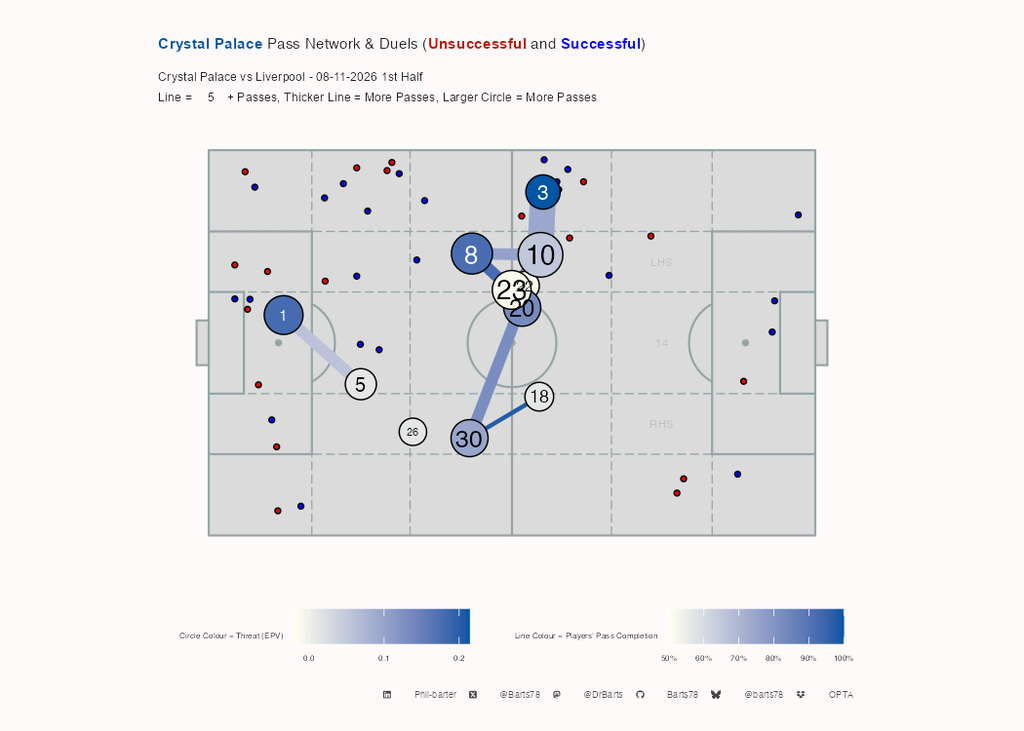

Away Pass Maps

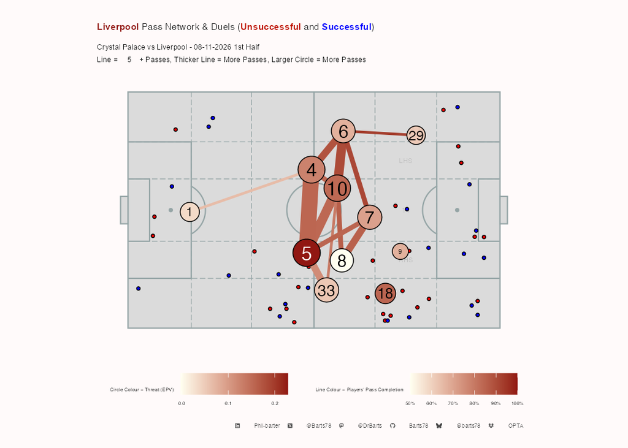

Home Pass Maps by Time

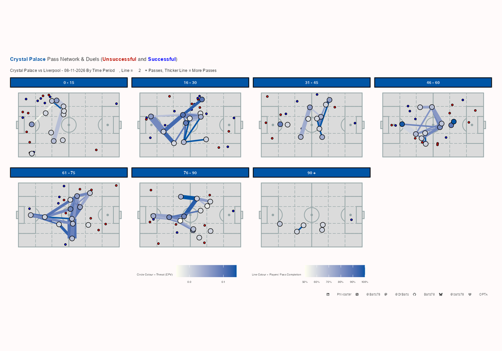

Away Pass Maps by Time

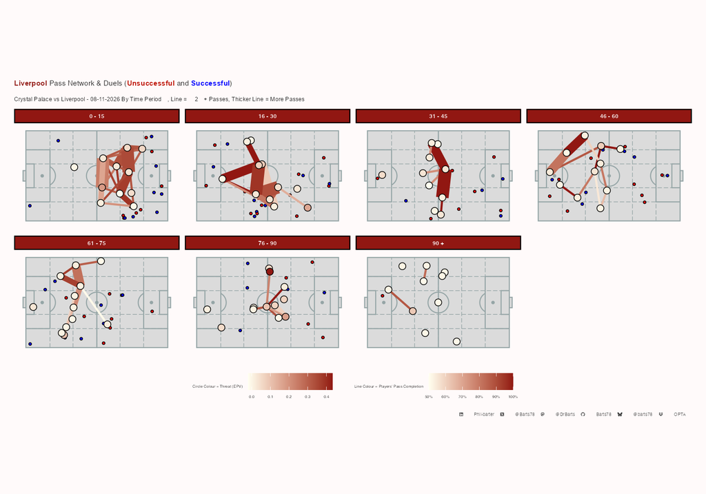

Home Attacking Pass Maps

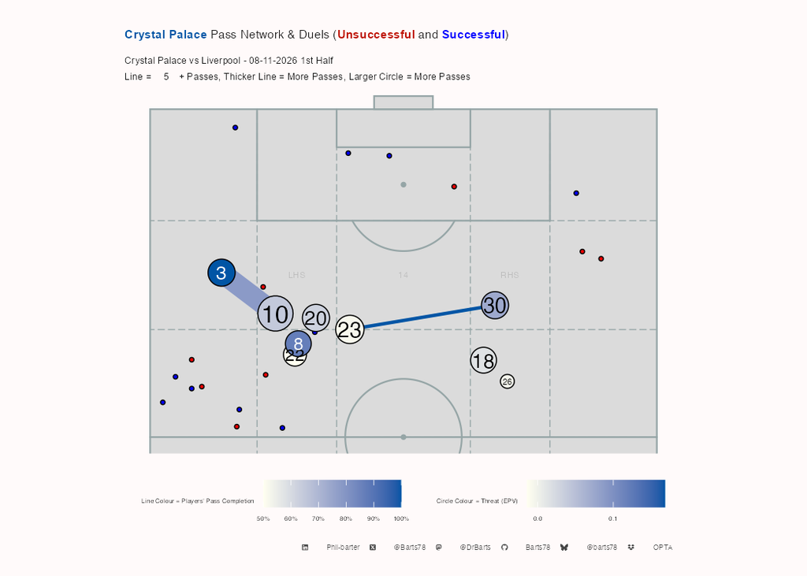

Away Attacking Pass Maps

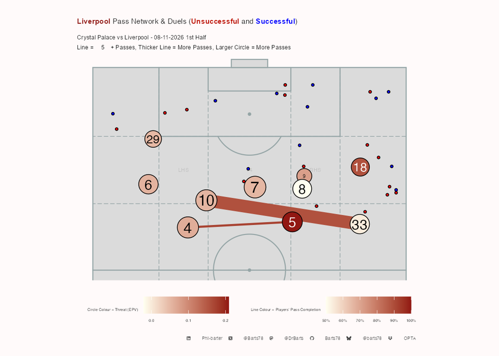

Home Attacking Pass Maps by Time

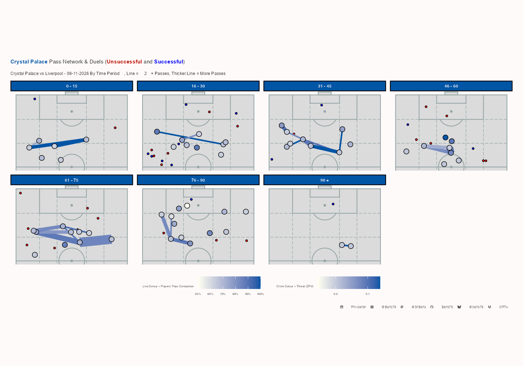

Away Attacking Pass Maps by Time

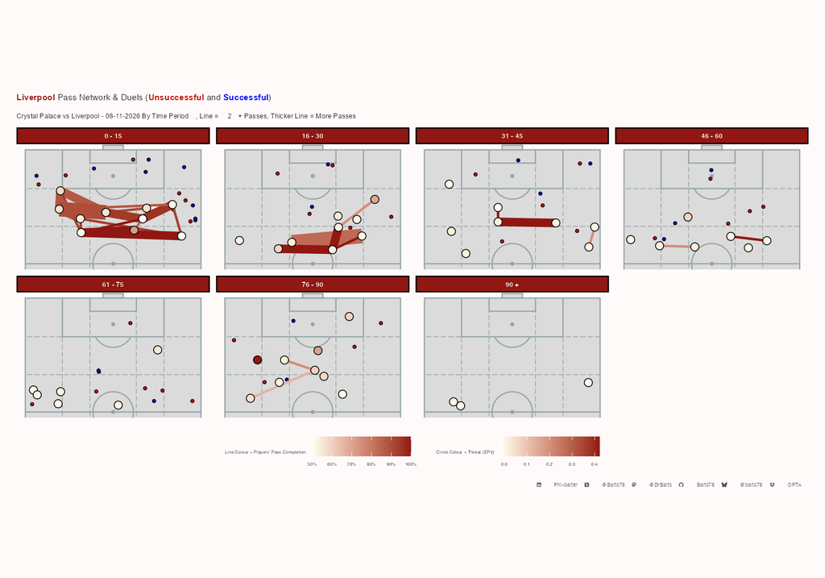

**Pass Connections by Passer**

Crystal Palace Open Play Passing connections

Crystal Palace vs Liverpool - 08-11-2026 | Completed passes only, min 5 per pair. Passer Completion % = all of the passer's attempts

|  | Completed Passes | % of Passer's Completions | % of Receiver's Receptions | Passer Completion % | Long Passes | Final Third Passes | PK Box Passes | Crosses | Key Passes | Prog Passes | EPV | EPV / Pass | Pass Time |
| --- | --- | --- | --- | --- | --- | --- | --- | --- | --- | --- | --- | --- | --- |
| Adam Wharton |  |  |  |  |  |  |  |  |  |  |  |  |  |
| Quinten Timber | 5 | 15% | 20% | 82% | 0 | 1 | 0 | 0 | 0 | 2 | 0.029 | 0.006 | 2.20 |
| Yéremy Pino | 7 | 21% | 14% | 82% | 0 | 3 | 0 | 0 | 0 | 0 | 0.038 | 0.005 | 3.43 |
| Axel Disasi |  |  |  |  |  |  |  |  |  |  |  |  |  |
| Chris Richards | 9 | 25% | 43% | 90% | 0 | 1 | 1 | 0 | 0 | 1 | 0.058 | 0.006 | 2.78 |
| Dean Henderson | 9 | 25% | 39% | 90% | 0 | 0 | 0 | 0 | 0 | 0 | 0.013 | 0.001 | 3.22 |
| Chris Richards |  |  |  |  |  |  |  |  |  |  |  |  |  |
| Óscar Mingueza | 6 | 24% | 23% | 83% | 0 | 0 | 0 | 0 | 0 | 0 | 0.008 | 0.001 | 2.17 |
| Daichi Kamada |  |  |  |  |  |  |  |  |  |  |  |  |  |
| Adam Wharton | 5 | 11% | 17% | 94% | 0 | 1 | 0 | 0 | 0 | 0 | 0.005 | 0.001 | 3.80 |
| Jefferson Lerma | 5 | 11% | 17% | 94% | 0 | 2 | 0 | 0 | 0 | 0 | 0.021 | 0.004 | 1.80 |
| Tyrick Mitchell | 5 | 11% | 18% | 94% | 3 | 2 | 0 | 0 | 0 | 3 | 0.043 | 0.009 | 3.20 |
| Yéremy Pino | 8 | 18% | 16% | 94% | 0 | 0 | 0 | 0 | 0 | 3 | 0.041 | 0.005 | 2.38 |
| Óscar Mingueza | 10 | 23% | 38% | 94% | 0 | 2 | 0 | 0 | 0 | 0 | 0.027 | 0.003 | 3.20 |
| Dean Henderson |  |  |  |  |  |  |  |  |  |  |  |  |  |
| Axel Disasi | 11 | 46% | 39% | 54% | 0 | 0 | 0 | 0 | 0 | 0 | 0.007 | 0.001 | 2.55 |
| Jefferson Lerma |  |  |  |  |  |  |  |  |  |  |  |  |  |
| Adam Wharton | 5 | 12% | 17% | 82% | 0 | 2 | 0 | 0 | 0 | 3 | 0.017 | 0.003 | 2.60 |
| Axel Disasi | 6 | 15% | 21% | 82% | 1 | 0 | 0 | 0 | 0 | 0 | 0.005 | 0.001 | 2.50 |
| Daichi Kamada | 5 | 12% | 14% | 82% | 0 | 0 | 0 | 0 | 0 | 1 | 0.014 | 0.003 | 2.40 |
| Tyrick Mitchell | 7 | 17% | 26% | 82% | 0 | 3 | 0 | 0 | 0 | 1 | 0.053 | 0.008 | 2.86 |
| Yéremy Pino | 9 | 22% | 18% | 82% | 1 | 3 | 0 | 0 | 1 | 3 | 0.034 | 0.004 | 2.67 |
| Tyrick Mitchell |  |  |  |  |  |  |  |  |  |  |  |  |  |
| Jefferson Lerma | 5 | 24% | 17% | 72% | 0 | 4 | 0 | 0 | 0 | 0 | 0.032 | 0.006 | 1.40 |
| Yéremy Pino | 7 | 33% | 14% | 72% | 1 | 4 | 0 | 0 | 1 | 1 | 0.150 | 0.021 | 2.57 |
| Yéremy Pino |  |  |  |  |  |  |  |  |  |  |  |  |  |
| Daichi Kamada | 7 | 21% | 19% | 69% | 1 | 0 | 0 | 0 | 0 | 0 | 0.018 | 0.003 | 2.43 |
| Quinten Timber | 6 | 18% | 24% | 69% | 0 | 2 | 0 | 0 | 1 | 0 | 0.018 | 0.003 | 2.00 |
| Tyrick Mitchell | 6 | 18% | 22% | 69% | 0 | 5 | 1 | 0 | 0 | 1 | 0.044 | 0.007 | 2.83 |
| Óscar Mingueza |  |  |  |  |  |  |  |  |  |  |  |  |  |
| Daichi Kamada | 5 | 17% | 14% | 88% | 0 | 1 | 0 | 0 | 0 | 1 | 0.022 | 0.004 | 1.80 |
| Quinten Timber | 6 | 21% | 24% | 88% | 1 | 3 | 0 | 0 | 0 | 3 | 0.050 | 0.008 | 2.33 |

X @Barts78 · Bluesky @barts78 · Mastodon @DrBarts · GitHub Barts78 · LinkedIn Phil-barter · Data: Opta

**Pass Connections by Receiver**

Crystal Palace Open Play Passing connections

Crystal Palace vs Liverpool - 08-11-2026 | Completed passes only, min 5 per pair. Passer Completion % = all of the passer's attempts

|  | Completed Passes | % of Passer's Completions | % of Receiver's Receptions | Passer Completion % | Long Passes | Final Third Passes | PK Box Passes | Crosses | Key Passes | Prog Passes | EPV | EPV / Pass | Pass Time |
| --- | --- | --- | --- | --- | --- | --- | --- | --- | --- | --- | --- | --- | --- |
| Quinten Timber |  |  |  |  |  |  |  |  |  |  |  |  |  |
| Adam Wharton | 5 | 15% | 20% | 82% | 0 | 1 | 0 | 0 | 0 | 2 | 0.029 | 0.006 | 2.20 |
| Yéremy Pino | 6 | 18% | 24% | 69% | 0 | 2 | 0 | 0 | 1 | 0 | 0.018 | 0.003 | 2.00 |
| Óscar Mingueza | 6 | 21% | 24% | 88% | 1 | 3 | 0 | 0 | 0 | 3 | 0.050 | 0.008 | 2.33 |
| Yéremy Pino |  |  |  |  |  |  |  |  |  |  |  |  |  |
| Adam Wharton | 7 | 21% | 14% | 82% | 0 | 3 | 0 | 0 | 0 | 0 | 0.038 | 0.005 | 3.43 |
| Daichi Kamada | 8 | 18% | 16% | 94% | 0 | 0 | 0 | 0 | 0 | 3 | 0.041 | 0.005 | 2.38 |
| Jefferson Lerma | 9 | 22% | 18% | 82% | 1 | 3 | 0 | 0 | 1 | 3 | 0.034 | 0.004 | 2.67 |
| Tyrick Mitchell | 7 | 33% | 14% | 72% | 1 | 4 | 0 | 0 | 1 | 1 | 0.150 | 0.021 | 2.57 |
| Chris Richards |  |  |  |  |  |  |  |  |  |  |  |  |  |
| Axel Disasi | 9 | 25% | 43% | 90% | 0 | 1 | 1 | 0 | 0 | 1 | 0.058 | 0.006 | 2.78 |
| Dean Henderson |  |  |  |  |  |  |  |  |  |  |  |  |  |
| Axel Disasi | 9 | 25% | 39% | 90% | 0 | 0 | 0 | 0 | 0 | 0 | 0.013 | 0.001 | 3.22 |
| Óscar Mingueza |  |  |  |  |  |  |  |  |  |  |  |  |  |
| Chris Richards | 6 | 24% | 23% | 83% | 0 | 0 | 0 | 0 | 0 | 0 | 0.008 | 0.001 | 2.17 |
| Daichi Kamada | 10 | 23% | 38% | 94% | 0 | 2 | 0 | 0 | 0 | 0 | 0.027 | 0.003 | 3.20 |
| Adam Wharton |  |  |  |  |  |  |  |  |  |  |  |  |  |
| Daichi Kamada | 5 | 11% | 17% | 94% | 0 | 1 | 0 | 0 | 0 | 0 | 0.005 | 0.001 | 3.80 |
| Jefferson Lerma | 5 | 12% | 17% | 82% | 0 | 2 | 0 | 0 | 0 | 3 | 0.017 | 0.003 | 2.60 |
| Jefferson Lerma |  |  |  |  |  |  |  |  |  |  |  |  |  |
| Daichi Kamada | 5 | 11% | 17% | 94% | 0 | 2 | 0 | 0 | 0 | 0 | 0.021 | 0.004 | 1.80 |
| Tyrick Mitchell | 5 | 24% | 17% | 72% | 0 | 4 | 0 | 0 | 0 | 0 | 0.032 | 0.006 | 1.40 |
| Tyrick Mitchell |  |  |  |  |  |  |  |  |  |  |  |  |  |
| Daichi Kamada | 5 | 11% | 18% | 94% | 3 | 2 | 0 | 0 | 0 | 3 | 0.043 | 0.009 | 3.20 |
| Jefferson Lerma | 7 | 17% | 26% | 82% | 0 | 3 | 0 | 0 | 0 | 1 | 0.053 | 0.008 | 2.86 |
| Yéremy Pino | 6 | 18% | 22% | 69% | 0 | 5 | 1 | 0 | 0 | 1 | 0.044 | 0.007 | 2.83 |
| Axel Disasi |  |  |  |  |  |  |  |  |  |  |  |  |  |
| Dean Henderson | 11 | 46% | 39% | 54% | 0 | 0 | 0 | 0 | 0 | 0 | 0.007 | 0.001 | 2.55 |
| Jefferson Lerma | 6 | 15% | 21% | 82% | 1 | 0 | 0 | 0 | 0 | 0 | 0.005 | 0.001 | 2.50 |
| Daichi Kamada |  |  |  |  |  |  |  |  |  |  |  |  |  |
| Jefferson Lerma | 5 | 12% | 14% | 82% | 0 | 0 | 0 | 0 | 0 | 1 | 0.014 | 0.003 | 2.40 |
| Yéremy Pino | 7 | 21% | 19% | 69% | 1 | 0 | 0 | 0 | 0 | 0 | 0.018 | 0.003 | 2.43 |
| Óscar Mingueza | 5 | 17% | 14% | 88% | 0 | 1 | 0 | 0 | 0 | 1 | 0.022 | 0.004 | 1.80 |

X @Barts78 · Bluesky @barts78 · Mastodon @DrBarts · GitHub Barts78 · LinkedIn Phil-barter · Data: Opta

**Away Pass Connections by Passer**

Liverpool Open Play Passing connections

Crystal Palace vs Liverpool - 08-11-2026 | Completed passes only, min 5 per pair. Passer Completion % = all of the passer's attempts

|  | Completed Passes | % of Passer's Completions | % of Receiver's Receptions | Passer Completion % | Long Passes | Final Third Passes | PK Box Passes | Crosses | Key Passes | Prog Passes | EPV | EPV / Pass | Pass Time |
| --- | --- | --- | --- | --- | --- | --- | --- | --- | --- | --- | --- | --- | --- |
| Alexis Mac Allister |  |  |  |  |  |  |  |  |  |  |  |  |  |
| Jérémy Jacquet | 5 | 14% | 19% | 80% | 1 | 2 | 0 | 0 | 0 | 0 | 0.011 | 0.002 | 2.60 |
| Milos Kerkez | 8 | 23% | 29% | 80% | 0 | 3 | 0 | 0 | 0 | 0 | 0.027 | 0.003 | 2.50 |
| Ronald Araujo | 7 | 20% | 27% | 80% | 4 | 1 | 0 | 0 | 0 | 0 | 0.012 | 0.002 | 3.43 |
| Alisson Becker |  |  |  |  |  |  |  |  |  |  |  |  |  |
| Virgil van Dijk | 9 | 50% | 36% | 62% | 0 | 0 | 0 | 0 | 0 | 0 | 0.008 | 0.001 | 13.44 |
| Florian Wirtz |  |  |  |  |  |  |  |  |  |  |  |  |  |
| Dominik Szoboszlai | 6 | 24% | 35% | 78% | 0 | 3 | 0 | 0 | 0 | 0 | 0.020 | 0.003 | 2.67 |
| Jérémy Jacquet |  |  |  |  |  |  |  |  |  |  |  |  |  |
| Alexis Mac Allister | 6 | 18% | 17% | 85% | 0 | 0 | 0 | 0 | 0 | 1 | 0.010 | 0.002 | 3.17 |
| Ronald Araujo | 7 | 21% | 27% | 85% | 0 | 0 | 0 | 0 | 0 | 0 | 0.009 | 0.001 | 2.71 |
| Virgil van Dijk | 6 | 18% | 24% | 85% | 1 | 0 | 0 | 0 | 0 | 0 | 0.005 | 0.001 | 5.50 |
| Milos Kerkez |  |  |  |  |  |  |  |  |  |  |  |  |  |
| Alexis Mac Allister | 6 | 20% | 17% | 83% | 0 | 0 | 0 | 0 | 0 | 0 | 0.011 | 0.002 | 2.33 |
| Bradley Barcola | 6 | 20% | 35% | 83% | 0 | 5 | 0 | 0 | 0 | 0 | 0.048 | 0.008 | 3.33 |
| Florian Wirtz | 6 | 20% | 23% | 83% | 0 | 2 | 0 | 0 | 0 | 3 | 0.022 | 0.004 | 2.83 |
| Virgil van Dijk |  |  |  |  |  |  |  |  |  |  |  |  |  |
| Alexis Mac Allister | 9 | 26% | 26% | 90% | 0 | 0 | 0 | 0 | 0 | 1 | 0.016 | 0.002 | 2.22 |
| Jérémy Jacquet | 7 | 20% | 27% | 90% | 0 | 1 | 1 | 0 | 0 | 1 | 0.077 | 0.011 | 2.71 |
| Milos Kerkez | 9 | 26% | 32% | 90% | 0 | 0 | 0 | 0 | 0 | 0 | 0.013 | 0.001 | 3.00 |

X @Barts78 · Bluesky @barts78 · Mastodon @DrBarts · GitHub Barts78 · LinkedIn Phil-barter · Data: Opta

**Away Pass Connections by Receiver**

Liverpool Open Play Passing connections

Crystal Palace vs Liverpool - 08-11-2026 | Completed passes only, min 5 per pair. Passer Completion % = all of the passer's attempts

|  | Completed Passes | % of Passer's Completions | % of Receiver's Receptions | Passer Completion % | Long Passes | Final Third Passes | PK Box Passes | Crosses | Key Passes | Prog Passes | EPV | EPV / Pass | Pass Time |
| --- | --- | --- | --- | --- | --- | --- | --- | --- | --- | --- | --- | --- | --- |
| Jérémy Jacquet |  |  |  |  |  |  |  |  |  |  |  |  |  |
| Alexis Mac Allister | 5 | 14% | 19% | 80% | 1 | 2 | 0 | 0 | 0 | 0 | 0.011 | 0.002 | 2.60 |
| Virgil van Dijk | 7 | 20% | 27% | 90% | 0 | 1 | 1 | 0 | 0 | 1 | 0.077 | 0.011 | 2.71 |
| Milos Kerkez |  |  |  |  |  |  |  |  |  |  |  |  |  |
| Alexis Mac Allister | 8 | 23% | 29% | 80% | 0 | 3 | 0 | 0 | 0 | 0 | 0.027 | 0.003 | 2.50 |
| Virgil van Dijk | 9 | 26% | 32% | 90% | 0 | 0 | 0 | 0 | 0 | 0 | 0.013 | 0.001 | 3.00 |
| Ronald Araujo |  |  |  |  |  |  |  |  |  |  |  |  |  |
| Alexis Mac Allister | 7 | 20% | 27% | 80% | 4 | 1 | 0 | 0 | 0 | 0 | 0.012 | 0.002 | 3.43 |
| Jérémy Jacquet | 7 | 21% | 27% | 85% | 0 | 0 | 0 | 0 | 0 | 0 | 0.009 | 0.001 | 2.71 |
| Virgil van Dijk |  |  |  |  |  |  |  |  |  |  |  |  |  |
| Alisson Becker | 9 | 50% | 36% | 62% | 0 | 0 | 0 | 0 | 0 | 0 | 0.008 | 0.001 | 13.44 |
| Jérémy Jacquet | 6 | 18% | 24% | 85% | 1 | 0 | 0 | 0 | 0 | 0 | 0.005 | 0.001 | 5.50 |
| Dominik Szoboszlai |  |  |  |  |  |  |  |  |  |  |  |  |  |
| Florian Wirtz | 6 | 24% | 35% | 78% | 0 | 3 | 0 | 0 | 0 | 0 | 0.020 | 0.003 | 2.67 |
| Alexis Mac Allister |  |  |  |  |  |  |  |  |  |  |  |  |  |
| Jérémy Jacquet | 6 | 18% | 17% | 85% | 0 | 0 | 0 | 0 | 0 | 1 | 0.010 | 0.002 | 3.17 |
| Milos Kerkez | 6 | 20% | 17% | 83% | 0 | 0 | 0 | 0 | 0 | 0 | 0.011 | 0.002 | 2.33 |
| Virgil van Dijk | 9 | 26% | 26% | 90% | 0 | 0 | 0 | 0 | 0 | 1 | 0.016 | 0.002 | 2.22 |
| Bradley Barcola |  |  |  |  |  |  |  |  |  |  |  |  |  |
| Milos Kerkez | 6 | 20% | 35% | 83% | 0 | 5 | 0 | 0 | 0 | 0 | 0.048 | 0.008 | 3.33 |
| Florian Wirtz |  |  |  |  |  |  |  |  |  |  |  |  |  |
| Milos Kerkez | 6 | 20% | 23% | 83% | 0 | 2 | 0 | 0 | 0 | 3 | 0.022 | 0.004 | 2.83 |

X @Barts78 · Bluesky @barts78 · Mastodon @DrBarts · GitHub Barts78 · LinkedIn Phil-barter · Data: Opta

Home Passing Tree Plot

[figure not shown]

Away Passing Tree Plot

[figure not shown]

Home wave plot

[figure not shown]

Away wave plot

[figure not shown]

**Home 1st Half Pass receiving Areas**

[figure not shown]

**Home 2nd Half Pass receiving Areas**

[figure not shown]

**Home Up to 1st Sub Pass receiving Areas**

[figure not shown]

**Away 1st Half Pass receiving Areas**

[figure not shown]

**Away 2nd Half Pass receiving Areas**

[figure not shown]

**Away Up to 1st Sub Pass receiving Areas**

[figure not shown]

Home Passing chains

[figure not shown]

Away Passing Chains

[figure not shown]

**Full time**

Crystal Palace FT Passing Chain Length (5, 6-10, 11-15, 16 +) & Distance (m)

Crystal Palace vs Liverpool - 08-11-2026

|  | Pass Chain Length | Total Chain Passes | Max Chain Length | Average Chain Length | Percent of Teams Passes | Total Chain Distance | Max Chain Distance | Average Chain Distance | Percent of Teams Passing Distance |
| --- | --- | --- | --- | --- | --- | --- | --- | --- | --- |
|  | VLow | 244 | 5 | 3 | 68% | 3,982.89 | 131.52 | 16.30 | 67% |
|  | Low | 113 | 10 | 8 | 32% | 2,003.41 | 276.80 | 17.70 | 33% |
| Overall Totals | — | 357 | 15 | 11 | — | 5,986 | 408 | 34 | — |
| Overall Average | — | 178 | 8 | 6 | — | 2,993 | 204 | 17 | — |

X @Barts78 · Bluesky @barts78 · Mastodon @DrBarts · GitHub Barts78 · LinkedIn Phil-barter · Data: Opta

**1st Half**

Crystal Palace 1st Half Passing Chain Length (5, 6-10, 11-15, 16 +) & Distance (m)

Crystal Palace vs Liverpool - 08-11-2026

|  | Pass Chain Length | Total Chain Passes | Max Chain Length | Average Chain Length | Percent of Teams Passes | Total Chain Distance | Max Chain Distance | Average Chain Distance | Percent of Teams Passing Distance |
| --- | --- | --- | --- | --- | --- | --- | --- | --- | --- |
|  | VLow | 109 | 5 | 2 | 70% | 1,815.14 | 131.52 | 16.70 | 66% |
|  | Low | 46 | 8 | 8 | 30% | 920.89 | 276.80 | 20.00 | 34% |
| Overall Totals | — | 155 | 13 | 10 | — | 2,736 | 408 | 37 | — |
| Overall Average | — | 78 | 6 | 5 | — | 1,368 | 204 | 18 | — |

X @Barts78 · Bluesky @barts78 · Mastodon @DrBarts · GitHub Barts78 · LinkedIn Phil-barter · Data: Opta

**2nd Half**

Crystal Palace 2nd Half Passing Chain Length (5, 6-10, 11-15, 16 +) & Distance (m)

Crystal Palace vs Liverpool - 08-11-2026

|  | Pass Chain Length | Total Chain Passes | Max Chain Length | Average Chain Length | Percent of Teams Passes | Total Chain Distance | Max Chain Distance | Average Chain Distance | Percent of Teams Passing Distance |
| --- | --- | --- | --- | --- | --- | --- | --- | --- | --- |
|  | VLow | 135 | 5 | 3 | 67% | 2,167.75 | 116.80 | 16.10 | 67% |
|  | Low | 67 | 10 | 9 | 33% | 1,082.52 | 193.36 | 16.20 | 33% |
| Overall Totals | — | 202 | 15 | 12 | — | 3,250 | 310 | 32 | — |
| Overall Average | — | 101 | 8 | 6 | — | 1,625 | 155 | 16 | — |

X @Barts78 · Bluesky @barts78 · Mastodon @DrBarts · GitHub Barts78 · LinkedIn Phil-barter · Data: Opta

**Away Full time**

Liverpool FT Passing Chain Length (5, 6-10, 11-15, 16 +) & Distance (m)

Crystal Palace vs Liverpool - 08-11-2026

|  | Pass Chain Length | Total Chain Passes | Max Chain Length | Average Chain Length | Percent of Teams Passes | Total Chain Distance | Max Chain Distance | Average Chain Distance | Percent of Teams Passing Distance |
| --- | --- | --- | --- | --- | --- | --- | --- | --- | --- |
|  | VLow | 183 | 5 | 3 | 61% | 3,035.10 | 110.56 | 16.60 | 58% |
|  | Low | 59 | 10 | 8 | 20% | 1,111.94 | 239.68 | 18.80 | 21% |
|  | Medium | 59 | 13 | 11 | 20% | 1,123.69 | 276.13 | 19.00 | 21% |
| Overall Totals | — | 301 | 28 | 22 | — | 5,271 | 626 | 54 | — |
| Overall Average | — | 100 | 9 | 7 | — | 1,757 | 209 | 18 | — |

X @Barts78 · Bluesky @barts78 · Mastodon @DrBarts · GitHub Barts78 · LinkedIn Phil-barter · Data: Opta

**Away 1st Half**

Liverpool 1st Half Passing Chain Length (5, 6-10, 11-15, 16 +) & Distance (m)

Crystal Palace vs Liverpool - 08-11-2026

|  | Pass Chain Length | Total Chain Passes | Max Chain Length | Average Chain Length | Percent of Teams Passes | Total Chain Distance | Max Chain Distance | Average Chain Distance | Percent of Teams Passing Distance |
| --- | --- | --- | --- | --- | --- | --- | --- | --- | --- |
|  | VLow | 96 | 5 | 3 | 57% | 1,542.49 | 106.41 | 16.10 | 52% |
|  | Low | 34 | 10 | 9 | 20% | 661.66 | 239.68 | 19.50 | 22% |
|  | Medium | 37 | 13 | 12 | 22% | 763.62 | 276.13 | 20.60 | 26% |
| Overall Totals | — | 167 | 28 | 24 | — | 2,968 | 622 | 56 | — |
| Overall Average | — | 56 | 9 | 8 | — | 989 | 207 | 19 | — |

X @Barts78 · Bluesky @barts78 · Mastodon @DrBarts · GitHub Barts78 · LinkedIn Phil-barter · Data: Opta

**Away 2nd Half**

Liverpool 2nd Half Passing Chain Length (5, 6-10, 11-15, 16 +) & Distance (m)

Crystal Palace vs Liverpool - 08-11-2026

|  | Pass Chain Length | Total Chain Passes | Max Chain Length | Average Chain Length | Percent of Teams Passes | Total Chain Distance | Max Chain Distance | Average Chain Distance | Percent of Teams Passing Distance |
| --- | --- | --- | --- | --- | --- | --- | --- | --- | --- |
|  | VLow | 87 | 5 | 2 | 65% | 1,492.61 | 110.56 | 17.20 | 65% |
|  | Low | 25 | 7 | 6 | 19% | 450.28 | 132.72 | 18.00 | 20% |
|  | Medium | 22 | 11 | 11 | 16% | 360.07 | 210.55 | 16.40 | 16% |
| Overall Totals | — | 134 | 23 | 19 | — | 2,303 | 454 | 52 | — |
| Overall Average | — | 45 | 8 | 6 | — | 768 | 151 | 17 | — |

X @Barts78 · Bluesky @barts78 · Mastodon @DrBarts · GitHub Barts78 · LinkedIn Phil-barter · Data: Opta

**Home Z14 RS By Half**

[figure not shown]

**Home Z14 RS By Game Period**

[figure not shown]

**Away Z14 RS By Half**

[figure not shown]

**Away Z14 RS By Game Period**

[figure not shown]

**Home Long Passes By half**

[figure not shown]

**Home Long Passes By Game Period**

[figure not shown]

**Away Long Passes By Half**

[figure not shown]

**Away Long Passes By Game period**

[figure not shown]

Set-Piece Summary

**Set Pieces**

Crystal Palace vs Liverpool - 08-11-2026

|  | Crystal Palace | Liverpool |
| --- | --- | --- |
| Corners |  |  |
| Corners taken | 4 | 7 |
| Short | 0 | 0 |
| Direct | 4 | 7 |
| Direct - first contact won | 1 (25%) | 3 (43%) |
| Free kicks |  |  |
| Free kicks (passes) | 17 | 13 |
| Into final third / box | 5 | 4 |
| Into box | 1 | 4 |
| Throw-ins |  |  |
| Throw-ins | 21 | 14 |
| Retained (first touch) | 57% | 71% |
| Shots by situation |  |  |
| Open-play shots | 14 | 12 |
| Open-play xG | 1.47 | 1.13 |
| Open-play goals | 0 | 2 |
| Set-piece shots | 4 | 8 |
| Set-piece xG | 0.37 | 1.52 |
| Set-piece goals | 0 | 1 |
| Penalties | 1 | 0 |
| Penalty xG | 0.79 | 0.00 |
| Set-piece share of xG | 14% | 57% |

First contact: the team that touches the ball first after the delivery (aerial duels go to the winner). Throw-ins retained = first touch by the taking team.  
X @Barts78 · Bluesky @barts78 · Mastodon @DrBarts · GitHub Barts78 · LinkedIn Phil-barter · Data: Opta

**Corners**

[figure not shown]

**Free Kicks**

[figure not shown]

**Corners**

[figure not shown]

**Free Kicks**

[figure not shown]

**Sequence Map**

[figure not shown]

**Sequence Table**

**Crystal Palace - Shot-Creating Sequences**

Crystal Palace vs Liverpool - 08-11-2026

| Min | Shooter | Result | xG | Situation | Started by | Started from | Start zone | Passes | Duration (s) |
| --- | --- | --- | --- | --- | --- | --- | --- | --- | --- |
| 18' | Pino | Post | 0.08 | Open play | Mitchell | Throw-in | Att third, Left wing | 9 | 20 |
| 18' | Pino | Saved | 0.04 | Open play | Mitchell | Throw-in | Att third, Left wing | 10 | 32 |
| 32' | Larsen | Blocked | 0.07 | Open play | Pino | Open-play regain | Def third, Left half-space | 2 | 8 |
| 33' | Pino | Off target | 0.06 | Set piece | Mingueza | Throw-in | Att third, Right wing | 2 | 10 |
| 33' | Kamada | Off target | 0.23 | Set piece | Mingueza | Throw-in | Att third, Right wing | 2 | 11 |
| 38' | Kamada | Saved | 0.13 | Open play | Mitchell | Throw-in | Mid third, Left wing | 6 | 17 |
| 41' | Timber | Blocked | 0.05 | Open play | Kamada | Open-play regain | Mid third, Central | 9 | 24 |
| 42' | Timber | Saved | 0.04 | Open play | Mitchell | Open-play regain | Att third, Left wing | 3 | 13 |
| 43' | Wharton | Saved | 0.23 | Open play | Pino | Open-play regain | Mid third, Left wing | 5 | 19 |
| 44' | Pino | Blocked | 0.02 | Set piece | Wharton | Corner | Att third, Right wing | 1 | 5 |
| 46' | Timber | Off target | 0.02 | Open play | Richards | Open-play regain | Def third, Right half-space | 3 | 11 |
| 74' | Pino | Blocked | 0.03 | Open play | Kamada | Open-play regain | Att third, Left half-space | 4 | 9 |
| 77' | Pino | Saved | 0.40 | Open play | Osorio | Open-play regain | Att third, Right half-space | 1 | 2 |
| 77' | Lerma | Saved | 0.06 | Open play | Osorio | Open-play regain | Att third, Right half-space | 1 | 3 |
| 78' | Nketiah | Off target | 0.23 | Open play | Disasi | Open-play regain | Mid third, Central | 10 | 30 |
| 86' | Richards | Off target | 0.06 | Set piece | Osorio | Corner | Att third, Left wing | 1 | 2 |
| 89' | McNeil | Blocked | 0.02 | Open play | Richards | Open-play regain | Def third, Right wing | 5 | 12 |
| 90+3' | Osorio | Off target | 0.07 | Open play | Osorio | Open-play regain | Mid third, Right wing | 7 | 39 |
| 90+5' | Nketiah | Goal | 0.79 | Penalty | Osorio | Open-play regain | Mid third, Right wing | 7 | 149 |

X @Barts78 · Bluesky @barts78 · Mastodon @DrBarts · GitHub Barts78 · LinkedIn Phil-barter · Data: Opta

**Sequence Map**

[figure not shown]

**Sequence Table**

**Liverpool - Shot-Creating Sequences**

Crystal Palace vs Liverpool - 08-11-2026

| Min | Shooter | Result | xG | Situation | Started by | Started from | Start zone | Passes | Duration (s) |
| --- | --- | --- | --- | --- | --- | --- | --- | --- | --- |
| 1' | Mac Allister | Saved | 0.03 | Open play | Barcola | Open-play regain | Att third, Central | 2 | 3 |
| 4' | Isak | Blocked | 0.05 | Open play | Barcola | Open-play regain | Mid third, Left half-space | 1 | 4 |
| 11' | Mac Allister | Off target | 0.02 | Set piece | Szoboszlai | Free kick | Att third, Left wing | 1 | 2 |
| 14' | Szoboszlai | Off target | 0.02 | Open play | Araujo | Throw-in | Att third, Right wing | 2 | 4 |
| 20' | Barcola | Off target | 0.10 | Open play | Araujo | Open-play regain | Mid third, Left half-space | 10 | 41 |
| 29' | Jacquet | Off target | 0.05 | Set piece | Szoboszlai | Corner | Att third, Right wing | 1 | 4 |
| 32' | Wirtz | Blocked | 0.05 | Open play | Jacquet | Open-play regain | Def third, Right wing | 18 | 55 |
| 37' | Barcola | Off target | 0.28 | Set piece | Araujo | Throw-in | Att third, Right wing | 2 | 4 |
| 40' | Mac Allister | Goal | 0.12 | Set piece | Szoboszlai | Free kick | Att third, Right wing | 1 | 2 |
| 45+2' | Wirtz | Blocked | 0.04 | Open play | Kerkez | Open-play regain | Def third, Left wing | 2 | 20 |
| 45+3' | Jacquet | Off target | 0.18 | Set piece | Szoboszlai | Corner | Att third, Right wing | 1 | 3 |
| 45+3' | Araujo | Saved | 0.76 | Set piece | Szoboszlai | Corner | Att third, Right wing | 1 | 4 |
| 54' | Wirtz | Goal | 0.19 | Open play | Araujo | Open-play regain | Def third, Right wing | 2 | 6 |
| 58' | Barcola | Blocked | 0.06 | Open play | Kerkez | Throw-in | Def third, Left wing | 3 | 8 |
| 59' | Araujo | Off target | 0.05 | Set piece | Szoboszlai | Corner | Att third, Right wing | 1 | 4 |
| 85' | Wirtz | Saved | 0.10 | Open play | Mac Allister | Open-play regain | Mid third, Central | 6 | 15 |
| 87' | Isak | Saved | 0.31 | Open play | Isak | Open-play regain | Mid third, Central | 2 | 5 |
| 88' | van Dijk | Off target | 0.06 | Set piece | van Dijk | Open-play regain | Att third, Central | 0 | 0 |
| 88' | Ngumoha | Saved | 0.03 | Open play | Jacquet | Open-play regain | Mid third, Left half-space | 1 | 6 |
| 89' | Isak | Goal | 0.15 | Open play | Nyoni | Open-play regain | Def third, Central | 4 | 15 |

X @Barts78 · Bluesky @barts78 · Mastodon @DrBarts · GitHub Barts78 · LinkedIn Phil-barter · Data: Opta

Entries by Channel

**Box and Final-Third Entries (open play)**

Crystal Palace vs Liverpool - 08-11-2026

|  | Box entries Passes | Box entries Carries | Box entries Total | Box entries Success % | Final-third entries Passes | Final-third entries Carries | Final-third entries Total | Final-third entries Success % |
| --- | --- | --- | --- | --- | --- | --- | --- | --- |
| Crystal Palace |  |  |  |  |  |  |  |  |
| Left wing | 8 | 3 | 11 | 36% | 4 | 3 | 7 | 100% |
| Left half-space | 8 | 0 | 8 | 50% | 14 | 5 | 19 | 58% |
| Central | 5 | 0 | 5 | 40% | 21 | 2 | 23 | 48% |
| Right half-space | 2 | 0 | 2 | 0% | 10 | 1 | 11 | 73% |
| Right wing | 4 | 0 | 4 | 75% | 4 | 0 | 4 | 75% |
| Total | 27 | 3 | 30 | 43% | 53 | 11 | 64 | 62% |
| Liverpool |  |  |  |  |  |  |  |  |
| Left wing | 3 | 5 | 8 | 75% | 6 | 1 | 7 | 71% |
| Left half-space | 5 | 1 | 6 | 67% | 9 | 0 | 9 | 56% |
| Central | 2 | 2 | 4 | 50% | 15 | 0 | 15 | 33% |
| Right half-space | 3 | 1 | 4 | 25% | 13 | 1 | 14 | 57% |
| Right wing | 6 | 1 | 7 | 43% | 12 | 1 | 13 | 69% |
| Total | 19 | 10 | 29 | 55% | 55 | 3 | 58 | 55% |

Channel = where the pass or carry started. Left/right from the attacking team's view. Set pieces excluded.  
X @Barts78 · Bluesky @barts78 · Mastodon @DrBarts · GitHub Barts78 · LinkedIn Phil-barter · Data: Opta

**Box**

[figure not shown]

**Final Third**

[figure not shown]

**Box**

[figure not shown]

**Final Third**

[figure not shown]

**Match Stats**

**Passing stats**

Crystal Palace vs Liverpool - 08-11-2026

|  | Name | Mins | % of Team Possession | xA | xT | Attempted Passes | Successful Passes | Pass Success % | Assists | BCs | Key Passes | Long Ps | Final 3rd P | Prog Ps | PK Box P | Pass Received | PPs Received | KPs Recieved | Recieveing Suc | EPV Recieved | EPV Created | % of Team EPV |
| --- | --- | --- | --- | --- | --- | --- | --- | --- | --- | --- | --- | --- | --- | --- | --- | --- | --- | --- | --- | --- | --- | --- |
| Keeper | Dean Henderson | 99 | 0.09 | 0 | 0.04 | 44 | 24 | 0.55 | 0 | 0 | 0 | 26 | 0 | 0 | 0 | 33 | 0 | 0 | 0.696969696969697 | 0.901 | 0.07 | 0.03 |
| Defender | Axel Disasi | 99 | 0.09 | 0 | 0.09 | 40 | 36 | 0.9 | 0 | 0 | 0 | 7 | 1 | 3 | 1 | 41 | 1 | 0 | 0.682926829268293 | 0.425 | 0.149 | 0.05 |
| Defender | Chris Richards | 99 | 0.06 | 0 | 0.03 | 30 | 25 | 0.83 | 0 | 0 | 0 | 3 | 3 | 2 | 2 | 32 | 1 | 1 | 0.6875 | 0.204 | 0.07 | 0.03 |
| Defender | Jefferson Lerma | 99 | 0.11 | 0 | 0.12 | 50 | 41 | 0.82 | 0 | 0 | 1 | 4 | 13 | 9 | 0 | 47 | 2 | 0 | 0.659574468085106 | 0.229 | 0.16 | 0.06 |
| Midfielder | Adam Wharton | 99 | 0.08 | 0 | 0.08 | 40 | 33 | 0.82 | 0 | 1 | 1 | 4 | 7 | 6 | 0 | 35 | 4 | 1 | 0.885714285714286 | 0.093 | 0.18 | 0.06 |
| Midfielder | Tyrick Mitchell | 99 | 0.1 | 0 | 0.66 | 29 | 21 | 0.72 | 0 | 0 | 3 | 2 | 15 | 5 | 1 | 34 | 5 | 0 | 0.794117647058823 | 0.252 | 0.815 | 0.29 |
| Midfielder | Óscar Mingueza | 91 | 0.09 | 0 | 0.39 | 33 | 29 | 0.88 | 0 | 0 | 2 | 3 | 7 | 7 | 2 | 32 | 0 | 0 | 0.8125 | 0.153 | 0.327 | 0.12 |
| Midfielder | Quinten Timber | 64 | 0.06 | 0.03 | 0.08 | 22 | 20 | 0.91 | 0 | 0 | 0 | 0 | 7 | 0 | 0 | 28 | 9 | 3 | 0.928571428571429 | 0.15 | 0.093 | 0.03 |
| Midfielder | Darío Osorio | 35 | 0.04 | 0 | 0.3 | 15 | 12 | 0.8 | 0 | 0 | 2 | 2 | 4 | 1 | 1 | 16 | 2 | 0 | 0.875 | 0.051 | 0.276 | 0.1 |
| Midfielder | Anan Khalaili | 8 | 0 | 0 | 0.01 | 2 | 1 | 0.5 | 0 | 0 | 1 | 0 | 1 | 0 | 0 | 3 | 0 | 0 | 0.333333333333333 | 0.005 | 0.005 | 0 |

[output cut: 5 more lines]

X @Barts78 · Bluesky @barts78 · Mastodon @DrBarts · GitHub Barts78 · LinkedIn Phil-barter · Data: Opta

**Touches and Carries**

Crystal Palace vs Liverpool - 08-11-2026

|  | Name | Mins | Touches | Def 3rd | Mid 3rd | Final 3rd | PK Box | Total / Min | Def 3rd % TT | Mid Third % TT | Final 3rd % TT | PK Box % TT | Carries | % Carries Prog | % Carries F 3rd | % Carries D Prog | Total Dribbles | Dribbles Won | Dribbles Lost | Dribble Success |
| --- | --- | --- | --- | --- | --- | --- | --- | --- | --- | --- | --- | --- | --- | --- | --- | --- | --- | --- | --- | --- |
| Keeper | Dean Henderson | 99 | 56 | 55 | 1 | 0 | 0 | 0.565656565656566 | 0.982142857142857 | 0.0178571428571429 | 0 | 0 | 4 | 0 | 0 | 0 | 0 | 0 | 0 | 0 |
| Defender | Axel Disasi | 99 | 55 | 39 | 15 | 1 | 1 | 0.555555555555556 | 0.709090909090909 | 0.272727272727273 | 0.0181818181818182 | 0.0181818181818182 | 5 | 0.2 | 0 | 0.210159362549801 | 0 | 0 | 0 | 0 |
| Defender | Chris Richards | 99 | 39 | 24 | 10 | 5 | 3 | 0.393939393939394 | 0.615384615384615 | 0.256410256410256 | 0.128205128205128 | 0.0769230769230769 | 2 | 0.5 | 0 | 0.59782977280434 | 0 | 0 | 0 | 0 |
| Defender | Jefferson Lerma | 99 | 68 | 25 | 26 | 17 | 1 | 0.686868686868687 | 0.367647058823529 | 0.382352941176471 | 0.25 | 0.0147058823529412 | 14 | 0.214285714285714 | 0.285714285714286 | 0.249609008445418 | 0 | 0 | 0 | 0 |
| Midfielder | Adam Wharton | 99 | 50 | 12 | 28 | 10 | 1 | 0.505050505050505 | 0.24 | 0.56 | 0.2 | 0.02 | 9 | 0.444444444444444 | 0.444444444444444 | 0.352047822925923 | 0 | 0 | 0 | 0 |
| Midfielder | Tyrick Mitchell | 99 | 64 | 19 | 20 | 25 | 4 | 0.646464646464647 | 0.296875 | 0.3125 | 0.390625 | 0.0625 | 4 | 0.25 | 1.25 | 0.334856915739269 | 2 | 0 | 2 | 0 |
| Midfielder | Óscar Mingueza | 91 | 58 | 22 | 20 | 16 | 2 | 0.637362637362637 | 0.379310344827586 | 0.344827586206897 | 0.275862068965517 | 0.0344827586206897 | 6 | 0.166666666666667 | 0.166666666666667 | 0.13110867979577 | 1 | 1 | 0 | 1 |
| Midfielder | Quinten Timber | 64 | 37 | 12 | 10 | 15 | 1 | 0.578125 | 0.324324324324324 | 0.27027027027027 | 0.405405405405405 | 0.027027027027027 | 5 | 0 | 0 | 0 | 2 | 0 | 2 | 0 |
| Midfielder | Darío Osorio | 35 | 25 | 2 | 13 | 10 | 4 | 0.714285714285714 | 0.08 | 0.52 | 0.4 | 0.16 | 3 | 0.333333333333333 | 0.333333333333333 | 0.32609860664523 | 0 | 0 | 0 | 0 |
| Midfielder | Anan Khalaili | 8 | 3 | 0 | 2 | 1 | 0 | 0.375 | 0 | 0.666666666666667 | 0.333333333333333 | 0 | 1 | 0 | 1 | 0 | 0 | 0 | 0 | 0 |

[output cut: 5 more lines]

X @Barts78 · Bluesky @barts78 · Mastodon @DrBarts · GitHub Barts78 · LinkedIn Phil-barter · Data: Opta

**Shooting stats**

Crystal Palace vs Liverpool - 08-11-2026

|  | Name | Mins | Total Shots | SoT | 6 yard box | PK Box Shot | Out Box Shots | Blocked Shot | Goals | xG | xGOT | xG/Shot | Shot Accuracy | Shot Quality |
| --- | --- | --- | --- | --- | --- | --- | --- | --- | --- | --- | --- | --- | --- | --- |
| Keeper | Dean Henderson | 99 | 0 | 0 | 0 | 0 | 0 | 0 | 0 | 0 | 0 | 0 | 0 | 0 |
| Defender | Axel Disasi | 99 | 0 | 0 | 0 | 0 | 0 | 0 | 0 | 0 | 0 | 0 | 0 | 0 |
| Defender | Chris Richards | 99 | 1 | 0 | 0 | 1 | 0 | 0 | 0 | 0.06 | 0 | 0.06 | 0 | -1 |
| Defender | Jefferson Lerma | 99 | 1 | 1 | 0 | 0 | 1 | 0 | 0 | 0.06 | 0.04 | 0.06 | 1 | -0.333333333333333 |
| Midfielder | Adam Wharton | 99 | 1 | 1 | 0 | 1 | 0 | 0 | 0 | 0.23 | 0.79 | 0.23 | 1 | 2.43478260869565 |
| Midfielder | Tyrick Mitchell | 99 | 0 | 0 | 0 | 0 | 0 | 0 | 0 | 0 | 0 | 0 | 0 | 0 |
| Midfielder | Óscar Mingueza | 91 | 0 | 0 | 0 | 0 | 0 | 0 | 0 | 0 | 0 | 0 | 0 | 0 |
| Midfielder | Quinten Timber | 64 | 3 | 1 | 0 | 1 | 2 | 1 | 0 | 0.11 | 0.01 | 0.0366666666666667 | 0.333333333333333 | -0.909090909090909 |
| Midfielder | Darío Osorio | 35 | 1 | 0 | 0 | 1 | 0 | 0 | 0 | 0.07 | 0 | 0.07 | 0 | -1 |
| Midfielder | Anan Khalaili | 8 | 0 | 0 | 0 | 0 | 0 | 0 | 0 | 0 | 0 | 0 | 0 | 0 |

[output cut: 5 more lines]

X @Barts78 · Bluesky @barts78 · Mastodon @DrBarts · GitHub Barts78 · LinkedIn Phil-barter · Data: Opta

**Defensive stats**

Crystal Palace vs Liverpool - 08-11-2026

|  | Name | Mins | Aerials Total | Aerials Won | Aerial Success % | Duels Total | Duels Won | Duel Success | Tackles Total | Tackles Won | Tackles Lost | Interceptions Total | Recoverys Total | Clearances Total | Fouls Total | Fouls Conceeded | Fouls Received | Offside Won | Offside Lost | EPV Faced | EPV Won | EPV Lost | Possession Control | Poss Control /100 Touches |
| --- | --- | --- | --- | --- | --- | --- | --- | --- | --- | --- | --- | --- | --- | --- | --- | --- | --- | --- | --- | --- | --- | --- | --- | --- |
| Keeper | Dean Henderson | 99 | 0 | 0 | 0 | 1 | 1 | 1 | 0 | 0 | 0 | 0 | 2 | 0 | 0 | 0 | 0 | 0 | 0 | 0.009 | 1 | 0 | -18 | -32.1 |
| Defender | Axel Disasi | 99 | 2 | 1 | 0.5 | 2 | 0 | 0 | 1 | 1 | 0 | 3 | 2 | 7 | 1 | 1 | 0 | 0 | 0 | 0.02 | 1 | 0 | 2 | 3.6 |
| Defender | Chris Richards | 99 | 3 | 3 | 1 | 2 | 1 | 0.5 | 2 | 1 | 1 | 0 | 1 | 5 | 0 | 0 | 0 | 0 | 0 | 0.033 | 1 | 0 | -2 | -5.1 |
| Defender | Jefferson Lerma | 99 | 6 | 4 | 0.666666666666667 | 9 | 4 | 0.444444444444444 | 4 | 2 | 2 | 1 | 6 | 4 | 5 | 2 | 3 | 0 | 0 | 0.035 | 1 | 0 | -1 | -1.5 |
| Midfielder | Adam Wharton | 99 | 2 | 1 | 0.5 | 6 | 3 | 0.5 | 3 | 2 | 1 | 1 | 2 | 1 | 3 | 1 | 2 | 0 | 0 | 0.072 | 0.930555555555555 | 0.0694444444444444 | -4 | -8 |
| Midfielder | Tyrick Mitchell | 99 | 1 | 0 | 0 | 8 | 3 | 0.375 | 1 | 1 | 0 | 1 | 6 | 4 | 4 | 1 | 3 | 0 | 1 | 0.009 | 0.888888888888889 | 0.111111111111111 | -11 | -17.2 |
| Midfielder | Óscar Mingueza | 91 | 1 | 0 | 0 | 8 | 2 | 0.25 | 3 | 3 | 0 | 0 | 8 | 2 | 3 | 3 | 0 | 0 | 1 | 0.078 | 0.576923076923077 | 0.423076923076923 | 1 | 1.7 |
| Midfielder | Quinten Timber | 64 | 0 | 0 | 0 | 6 | 4 | 0.666666666666667 | 2 | 1 | 1 | 0 | 3 | 1 | 3 | 0 | 3 | 0 | 0 | 0.017 | 1 | 0 | -5 | -13.5 |
| Midfielder | Darío Osorio | 35 | 2 | 2 | 1 | 3 | 2 | 0.666666666666667 | 0 | 0 | 0 | 0 | 1 | 0 | 3 | 1 | 2 | 0 | 0 | 0.005 | 0.8 | 0.2 | -3 | -12 |
| Midfielder | Anan Khalaili | 8 | 0 | 0 | 0 | 0 | 0 | 0 | 0 | 0 | 0 | 1 | 0 | 0 | 0 | 0 | 0 | 0 | 0 | 0 | 0 | 0 | 0 | 0 |

[output cut: 5 more lines]

Greyed Poss Control /100 Touches = fewer than 20 touches. | X @Barts78 · Bluesky @barts78 · Mastodon @DrBarts · GitHub Barts78 · LinkedIn Phil-barter · Data: Opta

**Match Stats**

**Passing stats**

Crystal Palace vs Liverpool - 08-11-2026